# Phân tích và so sánh các phương pháp giảm chiều và phân loại trong nhận diện cơn động kinh từ EEG ngắn hạn

22110012 - Hữu Ân 22110059 - Hồng Hiên

2025-06-29

# I. Tổng quan đề tài

**1.1. Bối cảnh và Vấn đề nghiên cứu**

Điện não đồ (EEG) là công cụ không thể thiếu trong chẩn đoán và theo dõi bệnh động kinh — một rối loạn thần kinh đặc trưng bởi các cơn co giật bất thường do hoạt động điện không ổn định trong não. Việc phát hiện chính xác và kịp thời các cơn động kinh có vai trò cốt lõi trong việc điều trị và nâng cao chất lượng sống cho người bệnh.

Tuy nhiên, quy trình phân tích tín hiệu EEG thủ công hiện nay bộc lộ nhiều hạn chế lớn: tốn nhiều thời gian, phụ thuộc nặng nề vào kinh nghiệm của chuyên gia dẫn đến tính chủ quan, và khó có thể mở rộng để đáp ứng nhu cầu sàng lọc trên quy mô lớn. Những thách thức này đòi hỏi một giải pháp thay thế hiệu quả hơn.

Để giải quyết vấn đề này, nghiên cứu đề xuất xây dựng và đánh giá một hệ thống học máy hoàn toàn tự động, với khả năng học hỏi các đặc trưng ẩn của tín hiệu và phân loại chính xác trạng thái co giật.

**1.2. Câu hỏi và Mục tiêu nghiên cứu**

Nghiên cứu này được định hướng bởi hai câu hỏi trọng tâm:

1. Liệu các đặc trưng được trích xuất từ miền thời gian, tần số và wavelet,… có đủ khả năng để phân biệt một cách đáng tin cậy giữa trạng thái co giật (seizure) và không co giật (non-seizure) từ các đoạn EEG ngắn hay không?
2. Việc áp dụng các kỹ thuật giảm chiều như Phân tích Thành phần Chính (PCA) ảnh hưởng như thế nào đến sự cân bằng giữa độ chính xác phân loại và hiệu quả tính toán của mô hình?

Dựa trên các câu hỏi đó, mục tiêu cuối cùng của nghiên cứu là xây dựng, so sánh và xác định mô hình phân loại hiệu quả nhất, từ đó cung cấp một phương pháp luận vững chắc cho việc phát hiện cơn động kinh tự động.

# II. Dữ liệu và Phương pháp luận

**2.1. Mô tả bộ dữ liệu**

**Nguồn gốc dữ liệu**

Nghiên cứu sử dụng bộ dữ liệu công khai **“Epileptic Seizure Recognition”** từ nền tảng Kaggle. Đây là một phiên bản đã qua xử lý của một bộ dữ liệu gốc nổi tiếng từ nghiên cứu của Andrzejak et al. (2001). Dữ liệu gốc được thu thập nhằm phân tích hoạt động điện não trong các trạng thái và vùng não khác nhau.

**Cấu trúc dữ liệu gốc**

Dữ liệu gốc bao gồm 5 bộ (datasets), ký hiệu từ A đến E, mỗi bộ chứa 100 tệp tín hiệu EEG đơn kênh, tương ứng với 5 nhóm đối tượng khác nhau:

- **Nhóm E (Tương ứng nhãn y=1):** Gồm các tín hiệu EEG được ghi lại **trong khi bệnh nhân đang có cơn co giật** (trạng thái ictal).
- **Nhóm D (Tương ứng nhãn y=2):** Tín hiệu được ghi từ vùng có khối u trong não của bệnh nhân giữa các cơn co giật (trạng thái interictal).
- **Nhóm C (Tương ứng nhãn y=3):** Tín hiệu được ghi từ vùng não khỏe mạnh ở bán cầu đối diện với vùng có khối u của bệnh nhân, cũng trong trạng thái interictal.
- **Nhóm B (Tương ứng nhãn y=4):** Tín hiệu từ những người tình nguyện khỏe mạnh khi đang **nhắm mắt**.
- **Nhóm A (Tương ứng nhãn y=5):** Tín hiệu từ những người tình nguyện khỏe mạnh khi đang **mở mắt**.

Mỗi tệp tín hiệu gốc có độ dài 4097 điểm dữ liệu, được ghi trong khoảng 23.5 giây.

**Quá trình tạo ra bộ dữ liệu trên Kaggle**

[Bộ dữ liệu Epileptic Seizure Recognition trên Kaggle](https://www.kaggle.com/datasets/yasserhessein/epileptic-seizure-recognition/data)

Để tạo ra bộ dữ liệu `.csv` được sử dụng trong nghiên cứu này, các nhà khoa học đã thực hiện các bước sau:

- Mỗi tín hiệu gốc (dài 4097 điểm) được chia thành 23 đoạn nhỏ không chồng chéo lên nhau.
- Mỗi đoạn nhỏ này có độ dài **178 điểm dữ liệu**, tương ứng với **1 giây** ghi nhận tín hiệu.
- Quá trình này tạo ra tổng cộng **11,500 mẫu** (500 tín hiệu gốc × 23 đoạn/tín hiệu). Mỗi mẫu này trở thành một hàng trong tệp `.csv`.

**Như vậy, bộ dữ liệu cuối cùng có cấu trúc:**

- **Cấu trúc:** 11,500 hàng (mẫu), mỗi hàng là một đoạn tín hiệu EEG dài 1 giây.
- **Đặc trưng:** Mỗi hàng có 178 cột đặc trưng (từ `X1` đến `X178`), đại diện cho các giá trị điện thế của tín hiệu.
- **Nhãn:** Mỗi hàng được gán một nhãn `y` từ 1 đến 5, tương ứng với 5 nhóm đối tượng ban đầu đã mô tả ở trên.

**2.2. Xác lập bài toán phân loại nhị phân**

Để tập trung vào mục tiêu chính là phát hiện cơn động kinh, bài toán đa lớp ban đầu được chuyển đổi thành một bài toán phân loại nhị phân. Các nhãn được xử lý như sau:

- **Lớp 1 (Seizure):** Gồm các đoạn tín hiệu được ghi lại trong lúc xảy ra cơn động kinh (nhãn gốc `y = 1`).
- **Lớp 0 (Non-Seizure):** Gồm tất cả các đoạn tín hiệu còn lại, bao gồm trạng thái mắt mở, mắt nhắm, và hoạt động não bình thường (nhãn gốc `y` từ 2 đến 5).

**2.3. Quy trình nghiên cứu tổng quan**

Nghiên cứu được triển khai theo một quy trình gồm 4 giai đoạn chính:

1. **Chuẩn bị dữ liệu:** Chuyển đổi bài toán sang dạng nhị phân (co giật/không co giật).
2. **Trích xuất đặc trưng (Feature Engineering):** Từ 178 điểm dữ liệu thô của mỗi mẫu, tiến hành trích xuất một bộ đặc trưng mới có ý nghĩa hơn, bao gồm các đặc trưng thống kê từ miền thời gian, năng lượng các dải tần số (Delta, Theta, Alpha, Beta, Gamma), và năng lượng các mức phân rã wavelet.
3. **Phân tích Khám phá và Giảm chiều:** Sử dụng các kỹ thuật thống kê đa biến (PCA, FA, MANOVA) và các phương pháp trực quan hóa phi tuyến (t-SNE, UMAP) để khám phá cấu trúc dữ liệu, kiểm tra khả năng phân tách của các lớp, và đánh giá hiệu quả của việc giảm chiều.
4. **Xây dựng và Đánh giá Mô hình:** Áp dụng kỹ thuật SMOTE trên tập huấn luyện để xử lý mất cân bằng lớp. Sau đó, huấn luyện và so sánh hiệu năng của các thuật toán (LDA, SVM, Random Forest) thông qua kiểm định chéo 10 lần. Cuối cùng, đánh giá mô hình tốt nhất trên tập kiểm tra để đưa ra kết luận cuối cùng.

```r
# Tải dữ liệu
df <- readr::read_csv("Epileptic Seizure Recognition.csv")

# Bỏ cột định danh đầu tiên.
df <- df %>% dplyr::select(-1)

# Chuyển đổi biến mục tiêu
# Cột mục tiêu là 'y'
df <- df %>%
  mutate(y = ifelse(y == 1, 1, 0))

# Hiện thị 6 dòng đầu
head(df)
```

```
## # A tibble: 6 × 179
##      X1    X2    X3    X4    X5    X6    X7    X8    X9   X10   X11   X12   X13
##   <dbl> <dbl> <dbl> <dbl> <dbl> <dbl> <dbl> <dbl> <dbl> <dbl> <dbl> <dbl> <dbl>
## 1   135   190   229   223   192   125    55    -9   -33   -38   -10    35    64
## 2   386   382   356   331   320   315   307   272   244   232   237   258   212
## 3   -32   -39   -47   -37   -32   -36   -57   -73   -85   -94   -99   -94   -96
## 4  -105  -101   -96   -92   -89   -95  -102  -100   -87   -79   -72   -68   -74
## 5    -9   -65   -98  -102   -78   -48   -16     0   -21   -59   -90  -103   -84
## 6    55    28    18    16    16    19    25    40    52    66    81    98   111
## # ℹ 166 more variables: X14 <dbl>, X15 <dbl>, X16 <dbl>, X17 <dbl>, X18 <dbl>,
## #   X19 <dbl>, X20 <dbl>, X21 <dbl>, X22 <dbl>, X23 <dbl>, X24 <dbl>,
## #   X25 <dbl>, X26 <dbl>, X27 <dbl>, X28 <dbl>, X29 <dbl>, X30 <dbl>,
## #   X31 <dbl>, X32 <dbl>, X33 <dbl>, X34 <dbl>, X35 <dbl>, X36 <dbl>,
## #   X37 <dbl>, X38 <dbl>, X39 <dbl>, X40 <dbl>, X41 <dbl>, X42 <dbl>,
## #   X43 <dbl>, X44 <dbl>, X45 <dbl>, X46 <dbl>, X47 <dbl>, X48 <dbl>,
## #   X49 <dbl>, X50 <dbl>, X51 <dbl>, X52 <dbl>, X53 <dbl>, X54 <dbl>, …
```

```r
# Tách tập đặc trưng (X) và biến mục tiêu (y)
X_original <- df %>% dplyr::select(-y)
y_labels <- df$y
```

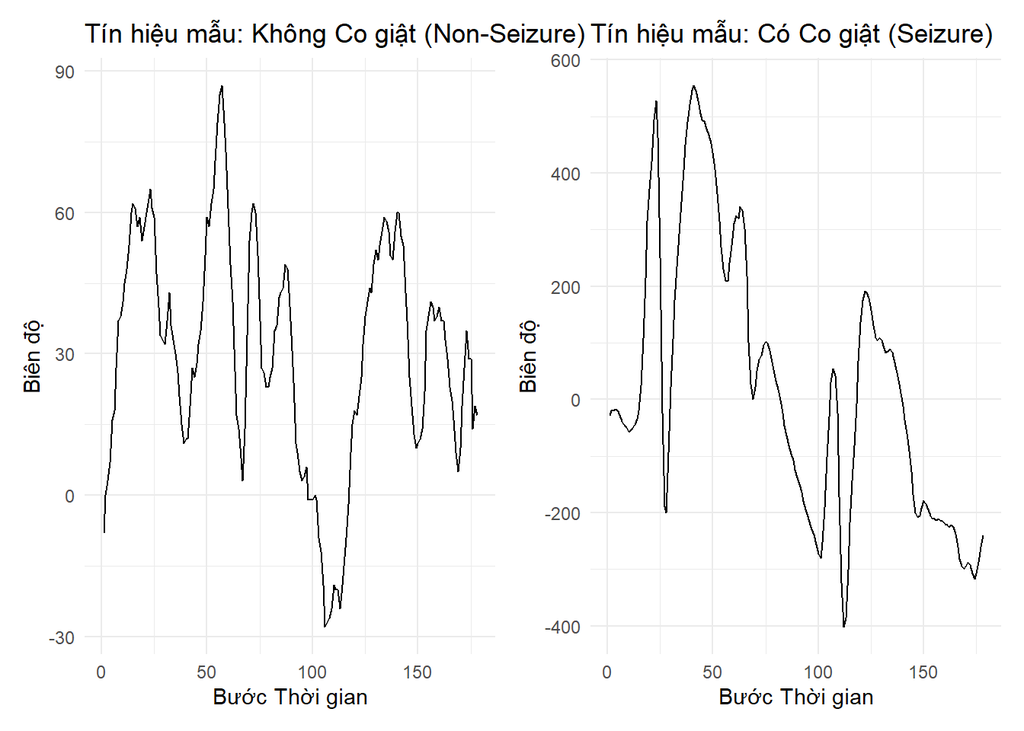

```r
library(patchwork) # Dùng để ghép 2 biểu đồ

# Lấy 1 mẫu KHÔNG co giật (y=0)
non_seizure_sample <- df %>% filter(y == 0) %>% sample_n(1) %>% dplyr::select(-y) %>% as.numeric()
# Lấy 1 mẫu CÓ co giật (y=1)
seizure_sample <- df %>% filter(y == 1) %>% sample_n(1) %>% dplyr::select(-y) %>% as.numeric()

# Hàm phụ để vẽ biểu đồ cho gọn
plot_eeg <- function(signal, plot_title) {
  tibble(time_step = 1:length(signal), amplitude = signal) %>%
    ggplot(aes(x = time_step, y = amplitude)) +
    geom_line() +
    labs(title = plot_title, x = "Bước Thời gian", y = "Biên độ") +
    theme_minimal()
}

# Vẽ 2 biểu đồ
p1 <- plot_eeg(non_seizure_sample, "Tín hiệu mẫu: Không Co giật (Non-Seizure)")
p2 <- plot_eeg(seizure_sample, "Tín hiệu mẫu: Có Co giật (Seizure)")

# Ghép 2 biểu đồ lại để so sánh
p1 + p2
```

# III. Trích xuất Đặc trưng (Feature Engineering)

## 3.1. Đặc trưng Miền Thời gian (Time Domain features)

Trước khi trích xuất ta vẽ một tín hiệu ngẫu nhiên theo miền thời gian

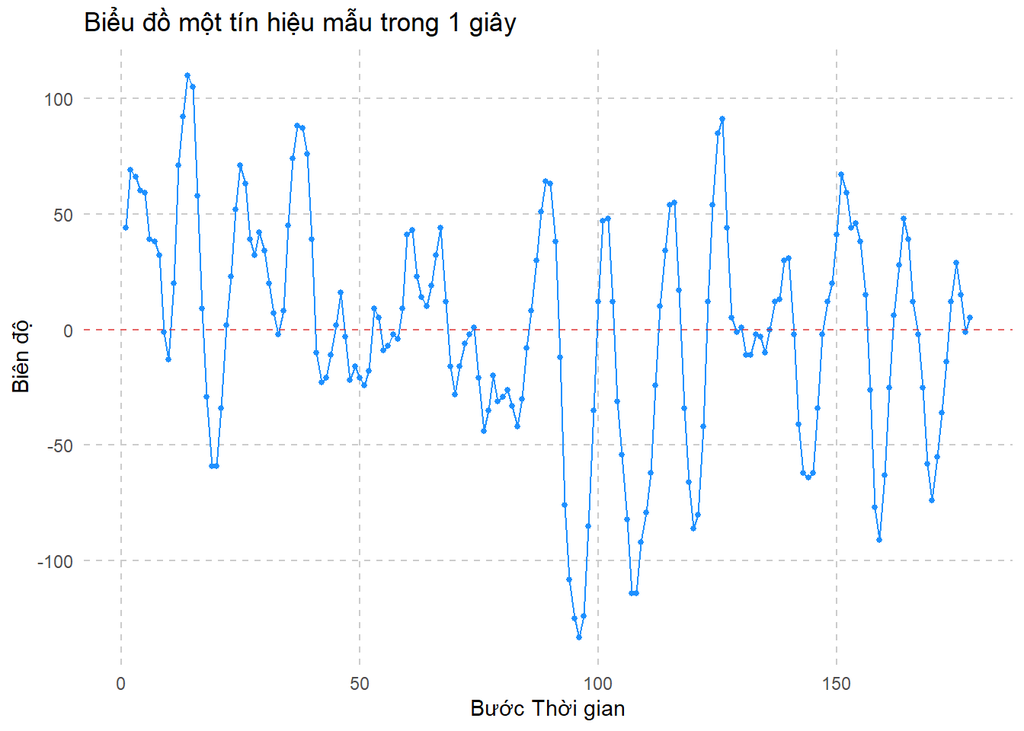

```r
# Lấy một mẫu tín hiệu ngẫu nhiên từ X
set.seed(42) # Để kết quả có thể tái lập
signal_sample <- X_original %>% dplyr::sample_n(1) %>% as.numeric()

# Tạo biểu đồ
tibble(
  time_step = 1:length(signal_sample),
  amplitude = signal_sample
) %>%
  ggplot(aes(x = time_step, y = amplitude)) +
  geom_line(color = "dodgerblue") +
  geom_point(color = "dodgerblue", size = 1) +
  geom_hline(yintercept = 0, linetype = "dashed", color = "red", alpha = 0.5) +
  labs(
    title = "Biểu đồ một tín hiệu mẫu trong 1 giây",
    x = "Bước Thời gian",
    y = "Biên độ"
  ) +
  theme_minimal() +
  # SỬA LỖI Ở ĐÂY
  theme(panel.grid.major = element_line(linetype = "dashed", color="gray80"),
        panel.grid.minor = element_blank())
```

Biểu đồ này được gọi là tín hiệu `miền thời gian` và cho thấy biên độ của tín hiệu thay đổi theo thời gian như thế nào. Từ biểu đồ này, chúng ta sẽ trích xuất một số thống kê tiêu chuẩn giúp mô tả đặc tính của tín hiệu. Chúng ta sẽ giải thích những cái ít phổ biến hơn ở dưới đây.

```r
# Hàm để trích xuất các đặc trưng miền thời gian
extract_time_domain_features <- function(signal) {
  # Các thống kê cơ bản
  mean_val <- mean(signal)
  std_val <- sd(signal)
  var_val <- var(signal)
  min_val <- min(signal)
  max_val <- max(signal)
  skew_val <- moments::skewness(signal)
  kurt_val <- moments::kurtosis(signal)
  rms_val <- sqrt(mean(signal^2))
  zero_crossings <- sum(diff(sign(signal)) != 0)

  # Giá trị tuyệt đối lớn nhất
  abs_max <- max(abs(c(min_val, max_val)))

  # Các hệ số (Factors)
  crest_factor <- abs_max / rms_val
  margin_factor <- abs_max / var_val
  shape_factor <- rms_val / mean(abs(signal))
  impulse_factor <- abs_max / mean(abs(signal))

  # Trả về một tibble (data frame)
  tibble(
    mean = mean_val, std = std_val, var = var_val, min = min_val, max = max_val,
    skew = skew_val, kurtosis = kurt_val, rms = rms_val,
    zero_crossings = zero_crossings, abs_max = abs_max,
    crest_factor = crest_factor, margin_factor = margin_factor,
    shape_factor = shape_factor, impulse_factor = impulse_factor
  )
}
```

**Crest factor** được định nghĩa là tỷ lệ giữa giá trị tuyệt đối lớn nhất của tín hiệu và giá trị RMS của nó:

$$C(y_n) = \frac{\max |y_n|}{RMS(y_n)} \qquad \text{với } RMS{(y_n)} =
\sqrt{\frac{1}{N} \sum_{n=1}^N y_n^2},$$

Điều này thể hiện đỉnh cao nhất lớn như thế nào so với công suất trung bình của tín hiệu. Nó cung cấp một thước đo về mức độ cực đoan của các đỉnh trong tín hiệu so với năng lượng tổng thể của nó.

**Margin factor** có khái niệm tương tự nhưng so sánh giá trị tuyệt đối lớn nhất với phương sai của tín hiệu:

$$M = \frac{\max |y_n|}{\text{Var}(y_n)}, \qquad \text{với }
\text{Var}(y_n) = \frac{1}{N} \sum_{n=1}^N \left( y_n - \bar{y}
\right)^2$$

Điều này phản ánh kích thước của đỉnh cao nhất so với độ phân tán (phương sai) của tín hiệu. Người đọc có thể nhận thấy rằng khi giá trị trung bình của tín hiệu bằng không, ví dụ như trong nhiễu trắng, crest factor và margin factor trùng nhau vì phương sai chính là RMS lấy trung tâm tại giá trị trung bình, tức là 0 trong trường hợp này.

**Shape factor** đo lường cách giá trị RMS so sánh với Giá trị Tuyệt đối Trung bình (Mean Absolute Value - MAV). Chỉ số này, thay vì định lượng đỉnh cực đại như các chỉ số trước, nó mô tả số lượng các đỉnh và cường độ của chúng. Lưu ý rằng các đỉnh càng cao, sự khác biệt giữa giá trị bình phương và giá trị tuyệt đối của nó càng lớn, do đó phân số tăng lên.

$$S(y_n) = \frac{\text{RMS}}{\text{MAV}}, \quad \text{MAV} = \frac{1}{N}
\sum_{n=1}^N |y_n|$$

**Impulse factor** là một thước đo liên quan khác, so sánh giá trị tuyệt đối lớn nhất với MAV. Tương tự, impulse factor làm nổi bật sự thống trị của đỉnh cao nhất của tín hiệu so với độ lớn điển hình của nó.

$$I = \frac{\max |y_n|}{\text{MAV}}$$

## 3.2. Đặc trưng Miền Tần số (Frequency Domain features)

Mục đích là chuyển đổi từ miền thời gian để phân tích sự phân bố của các tần số, được gọi là các dải công suất. Việc chuyển đổi tín hiệu EEG từ miền thời gian sang miền tần số cho phép chúng ta **tiết lộ các cấu trúc tuần hoàn ẩn, phân biệt các trạng thái nhận thức khác nhau, và phát hiện hoạt động thần kinh bất thường**, chẳng hạn như những gì thấy trong bệnh động kinh hoặc rối loạn giấc ngủ.

Một trong những phương pháp có thể được sử dụng cho việc này là phương pháp Welch, một kỹ thuật để ước tính **Mật độ Phổ Công suất (PSD)** của tín hiệu bằng cách giảm phương sai thông qua việc lấy trung bình nhiều biểu đồ chu kỳ (periodogram). Nó hoạt động bằng cách chia tín hiệu EEG thành các đoạn chồng chéo, áp dụng một hàm cửa sổ (như Hamming hoặc Hanning) để giảm rò rỉ phổ, tính toán **Biến đổi Fourier Rời rạc (DFT)** cho mỗi đoạn, và sau đó lấy trung bình các bình phương độ lớn của các đoạn đã biến đổi. Về mặt toán học, nếu $X_k(f)$ là biến đổi Fourier của đoạn thứ $k$, thì ước tính PSD của Welch được cho bởi:

$$S_{xx}(f) = \frac{1}{K} \sum_{k=1}^{K} \left| X_k(f) \right|^2$$

trong đó $K$ là số đoạn. Cách tiếp cận này cung cấp một ước tính PSD mượt mà hơn so với ước tính periodogram trực tiếp, cải thiện sự ổn định và giảm nhiễu trong phân tích tần số EEG.

| Dải Công suất | Dải Tần số (Hz) | Mô tả |
| --- | --- | --- |
| **Delta (δ)** | 0.5 – 4 Hz | Liên quan đến giấc ngủ sâu và các quá trình phục hồi. Sóng delta cao bất thường khi thức có thể chỉ ra tổn thương não hoặc động kinh. |
| **Theta (θ)** | 4 – 7 Hz | Liên quan đến trạng thái buồn ngủ, ngủ nông và xử lý bộ nhớ. Hoạt động theta tăng có thể xảy ra trước khi cơn co giật bắt đầu ở bệnh nhân động kinh. |
| **Alpha (α)** | 8 – 12 Hz | Tìm thấy trong trạng thái tỉnh táo thư giãn, đặc biệt là khi nhắm mắt. Sự triệt tiêu alpha được quan sát thấy trong các cơn co giật và sự tham gia nhận thức. |
| **Beta (β)** | 13 – 30 Hz | Liên quan đến suy nghĩ tích cực, giải quyết vấn đề và sự tỉnh táo. Các đợt bùng phát bất thường của sóng beta có thể thấy trong bệnh động kinh cục bộ. |
| **Gamma (γ)** | 30 – 100 Hz | Liên quan đến các chức năng nhận thức cấp cao và xử lý cảm giác. Hoạt động gamma tăng đôi khi được quan sát thấy trong các đợt co giật. |

```r
# Hàm trích xuất đặc trưng miền tần số
extract_frequency_domain_features <- function(signal, fs = 178) {
  # Tính toán phổ trung bình (tương tự phương pháp Welch) bằng hàm meanspec
  # wl = độ dài cửa sổ, bằng độ dài tín hiệu để không chia đoạn
  # `meanspec` trả về một ma trận với cột 1 là tần số (kHz) và cột 2 là biên độ
  mean_spec_res <- seewave::meanspec(signal, f = fs, wl = length(signal), plot = FALSE)

  freqs <- mean_spec_res[, 1] * 1000 # Chuyển từ kHz sang Hz
  psd <- mean_spec_res[, 2]

  # Hàm phụ để tính công suất dải tần
  bandpower <- function(psd, freqs, fmin, fmax) {
    idx <- freqs >= fmin & freqs <= fmax
    # Tích hợp bằng quy tắc hình thang (trapezoidal rule) từ package pracma
    power <- pracma::trapz(freqs[idx], psd[idx])
    return(power)
  }

  # Xác định các dải tần EEG điển hình (Hz)
  delta_power <- bandpower(psd, freqs, 0.5, 4)
  theta_power <- bandpower(psd, freqs, 4, 8)
  alpha_power <- bandpower(psd, freqs, 8, 13)
  beta_power <- bandpower(psd, freqs, 13, 30)
  gamma_power <- bandpower(psd, freqs, 30, fs / 2)

  tibble(
    delta_power = delta_power, theta_power = theta_power,
    alpha_power = alpha_power, beta_power = beta_power,
    gamma_power = gamma_power
  )
}
```

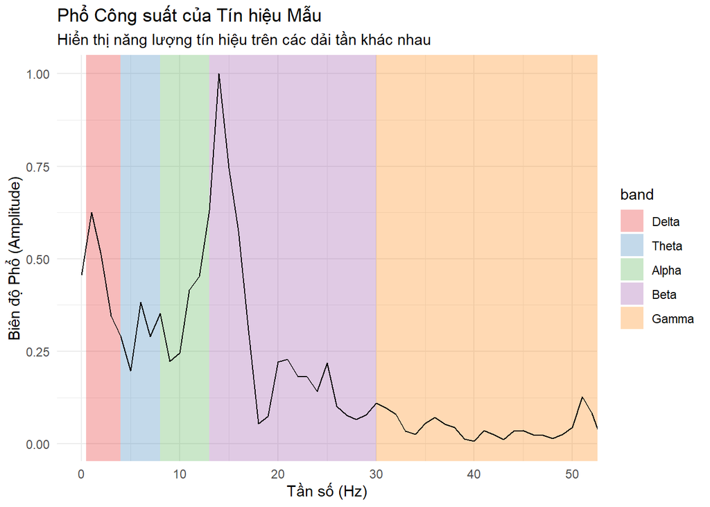

```r
# Lấy lại signal_sample nếu cần
set.seed(42)
signal_sample <- X_original %>% dplyr::sample_n(1) %>% as.numeric()
fs <- 178 # Tần số lấy mẫu

# Vẽ Phổ Công suất
# Sử dụng hàm meanspec từ package seewave để tính phổ
# wl = độ dài cửa sổ, ở đây bằng độ dài tín hiệu
mean_spec_res <- seewave::meanspec(signal_sample, f = fs, wl = length(signal_sample), plot = FALSE)

# Chuyển kết quả thành tibble để vẽ bằng ggplot
spectrum_df <- tibble(
  frequency = mean_spec_res[, 1] * 1000, # Chuyển từ kHz sang Hz
  amplitude = mean_spec_res[, 2]
)

# Tạo data frame để tô màu các dải tần EEG
eeg_bands <- tibble(
  band = factor(c("Delta", "Theta", "Alpha", "Beta", "Gamma"), levels = c("Delta", "Theta", "Alpha", "Beta", "Gamma")),
  fmin = c(0.5, 4, 8, 13, 30),
  fmax = c(4, 8, 13, 30, fs / 2)
)

# Vẽ biểu đồ
ggplot(spectrum_df, aes(x = frequency, y = amplitude)) +
  # Thêm các vùng chữ nhật để tô màu cho dải tần
  geom_rect(data = eeg_bands, aes(xmin = fmin, xmax = fmax, ymin = -Inf, ymax = Inf, fill = band),
            alpha = 0.3, inherit.aes = FALSE) +
  # Vẽ đường phổ
  geom_line(color = "black") +
  # Giới hạn trục x để nhìn rõ hơn
  coord_cartesian(xlim = c(0, 50)) +
  scale_fill_brewer(palette = "Set1") +
  labs(
    title = "Phổ Công suất của Tín hiệu Mẫu",
    subtitle = "Hiển thị năng lượng tín hiệu trên các dải tần khác nhau",
    x = "Tần số (Hz)",
    y = "Biên độ Phổ (Amplitude)"
  ) +
  theme_minimal()
```

## 3.3. Đặc trưng Wavelet và Phi tuyến tính

Biến đổi Wavelet (WT) đặc biệt hữu ích để phân tích tín hiệu EEG vì nó phân rã tín hiệu thành các thành phần tần số khác nhau trong khi vẫn duy trì độ phân giải thời gian. Biến đổi Wavelet Rời rạc (DWT) phân rã tín hiệu thành các mức chi tiết khác nhau: - **Thành phần tần số thấp (hệ số xấp xỉ)** nắm bắt các xu hướng dài hạn. - **Thành phần tần số cao (hệ số chi tiết)** phát hiện các mẫu tạm thời, tồn tại trong thời gian ngắn như các đỉnh nhọn động kinh.

Trong hàm sau, chúng ta áp dụng DWT sử dụng wavelet Daubechies-4 (“db4”), thường được sử dụng trong phân tích EEG. Năng lượng ở mỗi mức wavelet được trích xuất làm đặc trưng.

$$ApEn(m, r) = \phi(m) - \phi(m+1)$$
trong đó: - $m$ là chiều nhúng (độ dài của các chuỗi được so sánh). - $r$ là một ngưỡng dựa trên độ lệch chuẩn của tín hiệu. - $(m)$ đại diện cho **tổng tương quan dựa trên khoảng cách Chebyshev**.

Một giá trị **ApEn cao hơn** cho thấy tín hiệu bất thường hơn, trong khi một giá trị **ApEn thấp hơn** cho thấy tín hiệu dễ dự đoán hơn (ví dụ: các mẫu giấc ngủ sâu hoặc co giật).

```r
extract_wavelet_nonlinear_features <- function(signal) {

  # Đảm bảo độ dài tín hiệu là lũy thừa của 2
  if (log2(length(signal)) %% 1 != 0) {
      new_len <- 2^floor(log2(length(signal)))
      signal_for_dwt <- signal[1:new_len]
  } else {
      signal_for_dwt <- signal
  }

  dwt_res <- wavelets::dwt(signal_for_dwt, filter = "d4", n.levels = 4)
  wavelet_coeffs <- c(dwt_res@W, list(dwt_res@V[[4]]))
  level_names <- paste0("level_", 1:length(wavelet_coeffs))

  # Tạo một danh sách rỗng để lưu trữ tất cả các đặc trưng
  all_features <- list()

  # Lặp qua từng mức hệ số để trích xuất nhiều đặc trưng
  for (i in 1:length(wavelet_coeffs)) {
    coeffs <- wavelet_coeffs[[i]]
    level_name <- level_names[i]

    # Tính toán các đặc trưng thống kê
    all_features[[paste0(level_name, "_energy")]] <- sum(coeffs^2)
    all_features[[paste0(level_name, "_std")]] <- sd(coeffs)
    all_features[[paste0(level_name, "_skew")]] <- moments::skewness(coeffs)
    all_features[[paste0(level_name, "_kurt")]] <- moments::kurtosis(coeffs)
  }

  # Trả về dưới dạng tibble một hàng
  return(as_tibble(all_features))
}
```

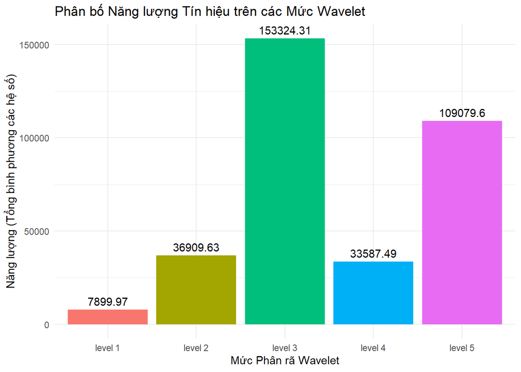

```r
# Trích xuất các đặc trưng wavelet từ signal_sample
wavelet_features <- extract_wavelet_nonlinear_features(signal_sample)

# Chuyển dữ liệu từ dạng rộng sang dạng dài để vẽ biểu đồ cột
wavelet_energy_df <- wavelet_features %>%
  # Chỉ chọn các cột năng lượng
  dplyr::select(ends_with("_energy")) %>%
  # Chuyển sang dạng dài
  pivot_longer(
    cols = everything(),
    names_to = "level",
    values_to = "energy"
  ) %>%
  # Sắp xếp lại tên cho đẹp
  mutate(level = sub("_energy", "", level) %>% sub("_", " ", .))

# Vẽ biểu đồ cột
ggplot(wavelet_energy_df, aes(x = level, y = energy, fill = level)) +
  geom_col(show.legend = FALSE) +
  geom_text(aes(label = round(energy, 2)), vjust = -0.5) +
  labs(
    title = "Phân bố Năng lượng Tín hiệu trên các Mức Wavelet",
    x = "Mức Phân rã Wavelet",
    y = "Năng lượng (Tổng bình phương các hệ số)"
  ) +
  theme_minimal()
```

Tính toán các đặc trưng

```r
# Áp dụng các hàm trích xuất đặc trưng
features_df_time <- purrr::map_dfr(1:nrow(X_original), ~extract_time_domain_features(as.numeric(X_original[.x, ])))
features_df_freq <- purrr::map_dfr(1:nrow(X_original), ~extract_frequency_domain_features(as.numeric(X_original[.x, ])))
features_df_wavelet <- purrr::map_dfr(1:nrow(X_original), ~extract_wavelet_nonlinear_features(as.numeric(X_original[.x, ])))

# Kết hợp tất cả các đặc trưng lại
features_df <- bind_cols(features_df_time, features_df_freq, features_df_wavelet)

# Hiện thị dữ liệu sau khi trích xuất
knitr::kable(head(features_df))
```

| mean | std | var | min | max | skew | kurtosis | rms | zero_crossings | abs_max | crest_factor | margin_factor | shape_factor | impulse_factor | delta_power | theta_power | alpha_power | beta_power | gamma_power | level_1_energy | level_1_std | level_1_skew | level_1_kurt | level_2_energy | level_2_std | level_2_skew | level_2_kurt | level_3_energy | level_3_std | level_3_skew | … |
| --- | --- | --- | --- | --- | --- | --- | --- | --- | --- | --- | --- | --- | --- | --- | --- | --- | --- | --- | --- | --- | --- | --- | --- | --- | --- | --- | --- | --- | --- | --- |
| -16.910112 | 95.98095 | 9212.3422 | -281 | 229 | -0.2003265 | 3.067411 | 97.19331 | 23 | 281 | 2.891145 | 0.0305026 | 1.256019 | 3.631334 | 1.6062961 | 0.4197943 | 1.7352695 | 3.4923819 | 1.0025972 | 21448.4024 | 18.444198 | -1.2191030 | 6.330508 | 160845.807 | 71.93656 | 0.1736332 | 2.467427 | 574188.774 | 195.14140 | -0.2194047 | … |
| 28.112360 | 473.16681 | 223886.8348 | -1716 | 513 | -1.5110878 | 4.341888 | 472.67256 | 8 | 1716 | 3.630420 | 0.0076646 | 1.258349 | 4.568335 | 2.0296054 | 1.6378022 | 1.1058821 | 2.0359529 | 0.3999603 | 858650.5485 | 116.247216 | -6.3288359 | 48.085528 | 2145740.380 | 261.54068 | -3.1642552 | 15.018346 | 2896222.892 | 435.07709 | -0.8288470 | … |
| -44.044944 | 44.31102 | 1963.4669 | -126 | 80 | 0.4944848 | 2.759586 | 62.38905 | 12 | 126 | 2.019585 | 0.0641722 | 1.157038 | 2.336737 | 0.6264894 | 0.6122287 | 0.6117973 | 1.3276679 | 0.4021459 | 3455.4185 | 7.404523 | -0.5028662 | 4.472331 | 20182.748 | 25.45484 | 0.3171029 | 2.505669 | 54767.712 | 60.24985 | -0.1409900 | … |
| -68.910112 | 15.96864 | 254.9975 | -105 | -22 | 0.3671253 | 3.212160 | 70.72601 | 0 | 105 | 1.484602 | 0.4117687 | 1.026352 | 1.523724 | 0.3890972 | 0.1300762 | 0.2156949 | 0.3954998 | 0.2064492 | 784.8627 | 3.529539 | 0.0995544 | 3.635150 | 3807.663 | 11.07984 | -0.0779136 | 1.892665 | 7230.956 | 21.56765 | 0.7991329 | … |
| -6.651685 | 38.80215 | 1505.6068 | -103 | 78 | -0.4627410 | 2.749484 | 39.26058 | 35 | 103 | 2.623496 | 0.0684110 | 1.269692 | 3.331032 | 1.7330114 | 1.5596436 | 1.9768357 | 5.1282318 | 2.1083559 | 5772.6024 | 9.563412 | 0.0344558 | 2.470001 | 47458.850 | 39.12421 | -0.2254847 | 2.629988 | 50615.191 | 57.25868 | -0.8126669 | … |
| 14.488764 | 49.08107 | 2408.9519 | -91 | 122 | -0.1042611 | 2.404310 | 51.04256 | 16 | 122 | 2.390162 | 0.0506444 | 1.207065 | 2.885080 | 1.2243719 | 0.5506760 | 1.7302941 | 2.2862829 | 0.5736323 | 4250.7952 | 8.211171 | -2.7332111 | 16.339580 | 22040.730 | 26.56440 | -0.3697690 | 2.931505 | 45032.179 | 54.78455 | 0.4420650 | … |

# IV. Phân tích Thống kê Nhiều chiều

Chúng ta sẽ khám phá bộ đặc trưng mới tạo ra bằng các phương pháp thống kê đa biến.

```r
X_features <- features_df
y_labels_factor <- as.factor(y_labels)

# Xác định các cột có phương sai gần bằng không (near-zero variance).
nzv_cols_indices <- nearZeroVar(X_features)

# In ra các cột bị loại bỏ (nếu có) để kiểm tra
if(length(nzv_cols_indices) > 0) {
  print("Loại bỏ các cột có phương sai gần bằng không:")
  print(names(X_features)[nzv_cols_indices])

  # Loại bỏ các cột này khỏi bộ dữ liệu
  X_features_filtered <- X_features[, -nzv_cols_indices]
} else {
  X_features_filtered <- X_features
}

# Chuẩn hóa trên bộ dữ liệu đã được lọc sạch
scaler <- preProcess(X_features_filtered, method = c("center", "scale"))
X_features_scaled <- predict(scaler, X_features_filtered)

# Kiểm tra
print(paste("Số giá trị không hữu hạn còn lại:", sum(!is.finite(as.matrix(X_features_scaled)))))
```

```
## [1] "Số giá trị không hữu hạn còn lại: 0"
```

## 4.1. Phân tích Thành phần chính (PCA)

PCA giúp giảm chiều dữ liệu trong khi vẫn giữ lại phần lớn thông tin (phương sai).

```r
pca_obj <- prcomp(X_features_scaled, scale. = TRUE)
```

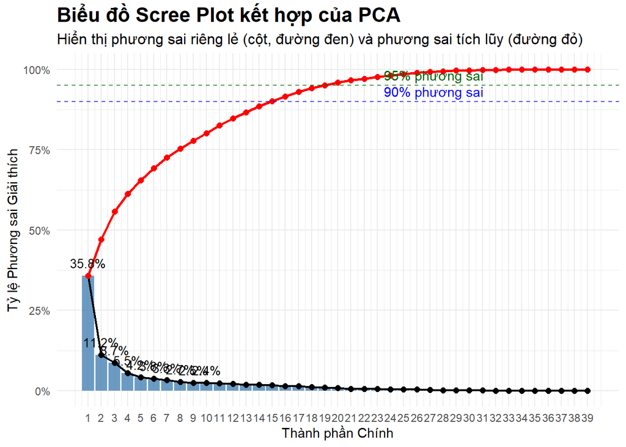

```r
# Lấy phương sai giải thích từ đối tượng PCA
explained_variance <- pca_obj$sdev^2 / sum(pca_obj$sdev^2)
cumulative_variance <- cumsum(explained_variance)

# Tạo dataframe để vẽ
plot_data <- tibble(
  component = 1:length(explained_variance),
  explained_variance = explained_variance,
  cumulative_variance = cumulative_variance
)

# Vẽ biểu đồ gộp
ggplot(plot_data, aes(x = component)) +
  # Vẽ các cột cho phương sai riêng lẻ
  geom_col(aes(y = explained_variance), fill = "steelblue", alpha = 0.8) +

  # Vẽ đường "khuỷu tay" nối các đỉnh cột
  geom_line(aes(y = explained_variance), color = "black", size = 0.8) +
  geom_point(aes(y = explained_variance), color = "black", size = 2) +

  # Vẽ đường tích lũy
  geom_line(aes(y = cumulative_variance), color = "red", size = 1) +
  geom_point(aes(y = cumulative_variance), color = "red", size = 2) +

  # Thêm nhãn % cho 10 thành phần đầu tiên
  geom_text(
    data = . %>% filter(component <= 10),
    # SỬA LỖI Ở ĐÂY: Thêm "scales::" vào trước hàm percent
    aes(y = explained_variance, label = scales::percent(explained_variance, accuracy = 0.1)),
    vjust = -0.8, # Đẩy chữ lên trên điểm
    size = 3.5,
    color = "black"
  ) +

  # Thêm các đường tham chiếu và chú thích
  geom_hline(yintercept = 0.9, linetype = "dashed", color = "blue", alpha = 0.7) +
  geom_hline(yintercept = 0.95, linetype = "dashed", color = "darkgreen", alpha = 0.7) +
  annotate("text", x = max(plot_data$component) * 0.7, y = 0.9, label = "90% phương sai", vjust = -0.5, color="blue") +
  annotate("text", x = max(plot_data$component) * 0.7, y = 0.95, label = "95% phương sai", vjust = -0.5, color="darkgreen") +

  # Tinh chỉnh các trục và tiêu đề
  scale_x_continuous(breaks = 1:length(explained_variance)) +
  scale_y_continuous(
    name = "Tỷ lệ Phương sai Giải thích",
    labels = scales::percent # Dòng này của bạn đã viết đúng
  ) +
  labs(
    title = "Biểu đồ Scree Plot kết hợp của PCA",
    subtitle = "Hiển thị phương sai riêng lẻ (cột, đường đen) và phương sai tích lũy (đường đỏ)",
    x = "Thành phần Chính",
    y = "Tỷ lệ Phương sai Giải thích"
  ) +
  theme_minimal() +
  theme(
    plot.title = element_text(size=16, face="bold"),
    plot.subtitle = element_text(size=12)
  )
```

**Nhận xét:**

**Kết luận:**

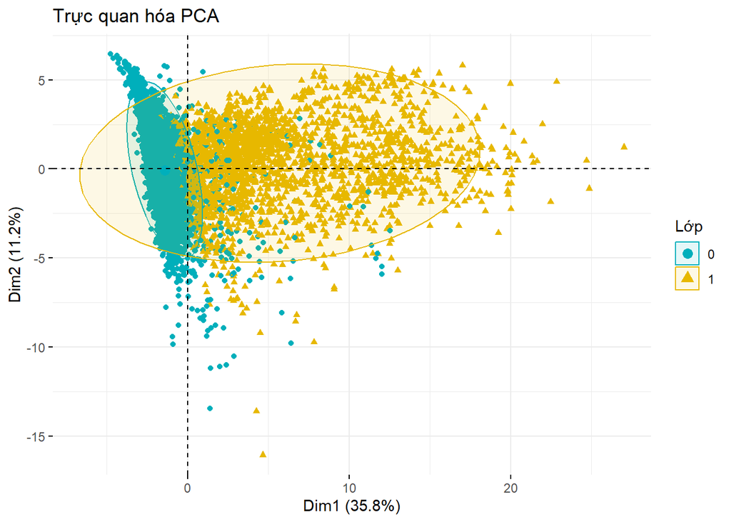

```r
library(factoextra)

# PCA Scatter Plot (PC1 vs PC2)
fviz_pca_ind(pca_obj,
             geom.ind = "point",
             col.ind = y_labels_factor,
             palette = c("#00AFBB", "#E7B800"),
             addEllipses = TRUE,
             legend.title = "Lớp") +
  labs(title="Trực quan hóa PCA")
```

Tuy nhiên, vẫn tồn tại một số điểm chồng lấn giữa hai lớp, đặc biệt là các điểm thuộc lớp 0 phân bố rải rác trong vùng của lớp 1. Điều này cho thấy biên phân tách giữa hai lớp không hoàn toàn tuyến tính. Do đó, các kỹ thuật giảm chiều phi tuyến như t-SNE hoặc UMAP sẽ được sử dụng bổ sung nhằm khảo sát rõ hơn cấu trúc phân lớp trong không gian đặc trưng phi tuyến.

```r
eigenvalues <- pca_obj$sdev^2
variance_percent <- eigenvalues / sum(eigenvalues) * 100

data.frame(
  PC = paste0("PC", 1:length(eigenvalues)),
  Eigenvalue = round(eigenvalues, 2),
  Variance_Percent = round(variance_percent, 2),
  Cumulative_Percent = round(cumsum(variance_percent), 2)
)
```

```
##      PC Eigenvalue Variance_Percent Cumulative_Percent
## 1   PC1      13.98            35.83              35.83
## 2   PC2       4.37            11.20              47.04
## 3   PC3       3.40             8.72              55.76
## 4   PC4       2.16             5.55              61.31
## 5   PC5       1.65             4.22              65.52
## 6   PC6       1.48             3.79              69.31
## 7   PC7       1.27             3.25              72.57
## 8   PC8       1.06             2.72              75.29
## 9   PC9       0.97             2.48              77.77
## 10 PC10       0.95             2.42              80.20
## 11 PC11       0.92             2.36              82.55
## 12 PC12       0.84             2.15              84.70
## 13 PC13       0.75             1.93              86.63
## 14 PC14       0.72             1.84              88.47
```

[output cut: 25 more lines]

Sử dụng tiêu chí Kaiser

```r
eigenvalues <- pca_obj$sdev^2
selected_pcs <- sum(eigenvalues > 1)
selected_pcs
```

```
## [1] 8
```

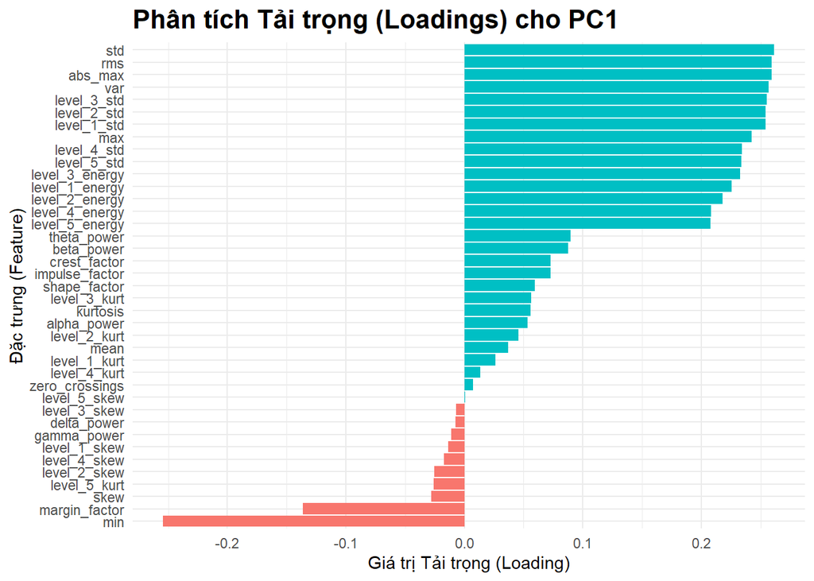

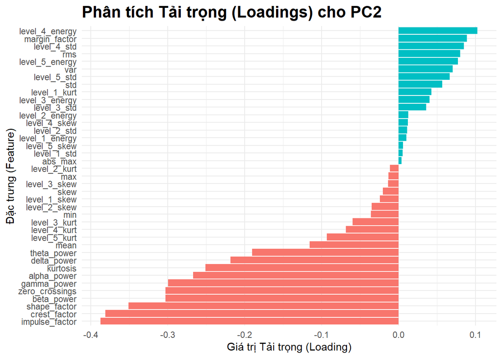

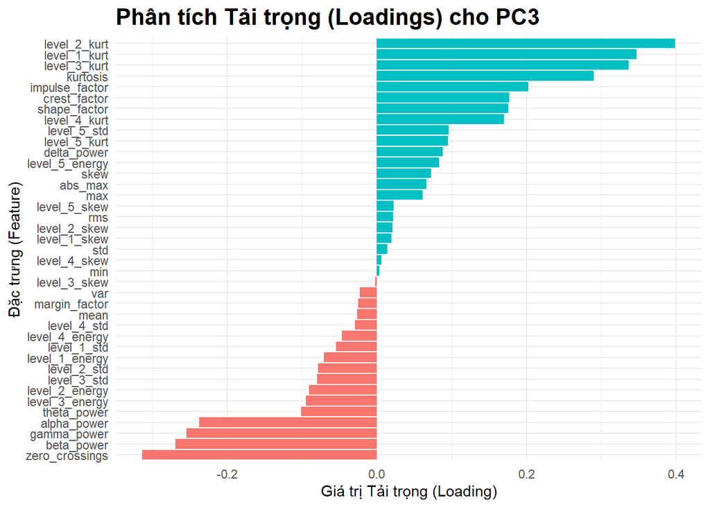

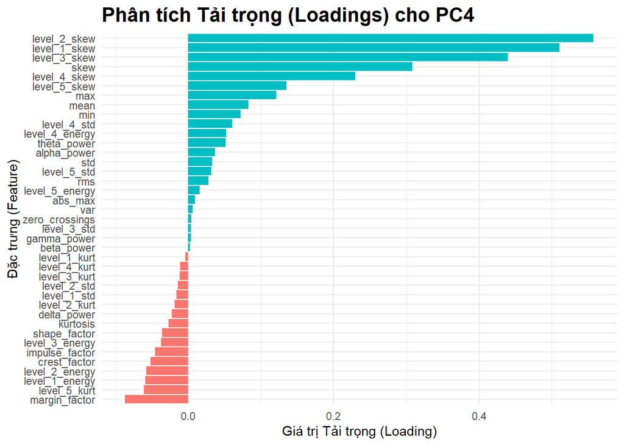

```r
# Lấy tải trọng (loadings) của 4 PC đầu tiên và chuyển sang dạng tidy
loadings_long <- as.data.frame(pca_obj$rotation[, 1:4]) %>%
  mutate(feature = rownames(.)) %>%
  # Chuyển từ dạng rộng sang dạng dài
  tidyr::pivot_longer(
    cols = c(PC1, PC2, PC3, PC4),
    names_to = "pc",
    values_to = "loading"
  )

# Lặp qua từng PC để vẽ và in ra biểu đồ riêng biệt
pc_names <- unique(loadings_long$pc)

for (pc_name in pc_names) {

  # Lọc dữ liệu chỉ cho PC hiện tại
  plot_data <- loadings_long %>%
    filter(pc == pc_name)

  # Tạo biểu đồ cho PC hiện tại
  p <- ggplot(plot_data, aes(y = loading,
                             x = reorder(feature, loading),
                             fill = loading > 0)) + # Tô màu khác nhau cho giá trị âm/dương
    geom_col(show.legend = FALSE) +
    coord_flip() + # Lật trục để dễ đọc tên đặc trưng
    labs(
      title = paste("Phân tích Tải trọng (Loadings) cho", pc_name), # Tiêu đề động
      x = "Đặc trưng (Feature)",
      y = "Giá trị Tải trọng (Loading)"
    ) +
    theme_minimal() +
    theme(
      plot.title = element_text(size = 16, face = "bold")
    )

  # In biểu đồ ra output
  print(p)
}
```

**Diễn giải các thành phần chính**

**PC1 - Độ lớn và sự Biến động chung của Tín hiệu**

Thành phần chính 1 (PC1) nắm bắt sự biến thiên tổng thể về biên độ và năng lượng của tín hiệu EEG. Nó có mối tương quan chặt chẽ với các đặc trưng đo lường độ lớn và năng lượng tín hiệu như `abs_max` (giá trị tuyệt đối lớn nhất), `std` (độ lệch chuẩn), `rms` (giá trị hiệu dụng), và `var` (phương sai). Đồng thời, tất cả các mức năng lượng wavelet (`wavelet_energy_level_1` đến `5`) đều có tải trọng dương cao, khẳng định vai trò của PC1 trong việc đo lường năng lượng trên toàn bộ phổ tần số. Nhìn chung, PC1 giúp phân biệt giữa các tín hiệu có năng lượng cao, dao động mạnh (điển hình của cơn co giật) và các tín hiệu có biên độ thấp, ổn định hơn.

**PC2 - Sự đối lập giữa Năng lượng Thô và Đặc tính Phổ**

- **Tải trọng dương cao:** `wavelet_energy_level_4`, `rms`, `var` -> Năng lượng tín hiệu thô cao.
- **Tải trọng âm cao:** `crest_factor`, `impulse_factor`, tất cả các `power_band` -> Tín hiệu có đỉnh nhọn và năng lượng phổ cụ thể.

**PC3 - Độ phức tạp và Hoạt động Tần số cao**

**PC4 - Đặc tính Đỉnh nhọn và Tần số Trung-Thấp**

## 4.2. Phân tích Nhân tố (Factor Analysis - FA)

FA giúp tìm ra các “nhân tố” tiềm ẩn (các biến không quan sát được) cấu thành nên các đặc trưng quan sát được của chúng ta.

```r
# Kiểm định KMO
cat("--- Kết quả Kiểm định KMO ---\n")
```

```
## --- Kết quả Kiểm định KMO ---
```

```r
kmo_result <- KMO(X_features_scaled)
print(kmo_result)
```

```
## Kaiser-Meyer-Olkin factor adequacy
## Call: KMO(r = X_features_scaled)
## Overall MSA =  0.84
## MSA for each item =
##           mean            std            var            min            max
##           0.60           0.87           0.86           0.92           0.92
##           skew       kurtosis            rms zero_crossings        abs_max
##           0.53           0.80           0.91           0.80           0.94
##   crest_factor  margin_factor   shape_factor impulse_factor    delta_power
##           0.63           0.86           0.57           0.62           0.69
##    theta_power    alpha_power     beta_power    gamma_power level_1_energy
##           0.84           0.86           0.87           0.72           0.83
##    level_1_std   level_1_skew   level_1_kurt level_2_energy    level_2_std
##           0.84           0.56           0.55           0.81           0.86
##   level_2_skew   level_2_kurt level_3_energy    level_3_std   level_3_skew
##           0.59           0.70           0.88           0.92           0.81
##   level_3_kurt level_4_energy    level_4_std   level_4_skew   level_4_kurt
##           0.85           0.85           0.90           0.87           0.82
## level_5_energy    level_5_std   level_5_skew   level_5_kurt
##           0.82           0.89           0.53           0.85
```

```r
# Kiểm định Bartlett
cat("\n--- Kết quả Kiểm định Bartlett ---\n")
```

```
##
## --- Kết quả Kiểm định Bartlett ---
```

```r
bartlett_result <- cortest.bartlett(X_features_scaled)
print(bartlett_result)
```

```
## $chisq
## [1] 724278.8
##
## $p.value
## [1] 0
##
## $df
## [1] 741
```

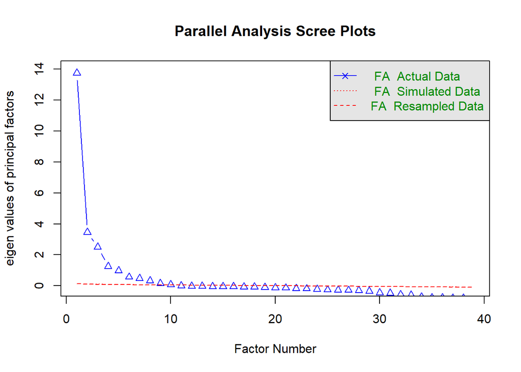

```
## Parallel analysis suggests that the number of factors =  10  and the number of components =  NA
```

```r
library(psych)

# Parallel Analysis (bạn đã làm)
fa.parallel(X_features_scaled, fa="fa")
```

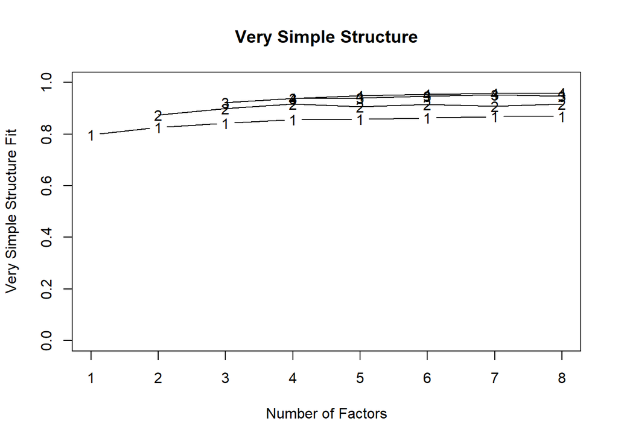

```
##
## Very Simple Structure
## Call: vss(x = x, n = n, rotate = rotate, diagonal = diagonal, fm = fm,
##     n.obs = n.obs, plot = plot, title = title, use = use, cor = cor)
## VSS complexity 1 achieves a maximimum of 0.87  with  7  factors
## VSS complexity 2 achieves a maximimum of 0.92  with  4  factors
##
## The Velicer MAP achieves a minimum of 0.03  with  7  factors
## BIC achieves a minimum of  153651.8  with  8  factors
## Sample Size adjusted BIC achieves a minimum of  155104.1  with  8  factors
##
## Statistics by number of factors
##   vss1 vss2   map dof  chisq prob sqresid  fit RMSEA    BIC  SABIC complex
## 1 0.80 0.00 0.059 702 409027    0    49.3 0.80  0.22 402464 404694     1.0
## 2 0.83 0.87 0.059 664 352972    0    30.6 0.87  0.21 346763 348873     1.2
## 3 0.84 0.90 0.045 627 289546    0    19.2 0.92  0.20 283684 285676     1.4
## 4 0.86 0.92 0.045 591 274901    0    14.9 0.94  0.20 269375 271253     1.3
## 5 0.86 0.91 0.043 556 208970    0    12.5 0.95  0.18 203771 205538     1.5
## 6 0.86 0.91 0.042 522 199662    0    10.6 0.96  0.18 194781 196440     1.4
## 7 0.87 0.91 0.031 489 172631    0     8.7 0.96  0.17 168059 169613     1.5
## 8 0.87 0.92 0.032 457 157925    0     7.9 0.97  0.17 153652 155104     1.5
##   eChisq  SRMR eCRMS   eBIC
## 1 310216 0.135 0.139 303652
## 2 157481 0.096 0.102 151272
## 3  67160 0.063 0.068  61297
## 4  44560 0.051 0.057  39035
## 5  28277 0.041 0.047  23078
## 6  17275 0.032 0.038  12394
## 7  10007 0.024 0.030   5435
## 8   6023 0.019 0.024   1750
```

```r
# Velicer's MAP
VSS(X_features_scaled)  # chọn số yếu tố theo độ phù hợp mô hình
```

Biểu đồ Parallel Analysis (hình dưới) được sử dụng để xác định số lượng nhân tố tiềm ẩn nên giữ lại trong phân tích nhân tố. Đường màu xanh biểu diễn các trị riêng (eigenvalues) thu được từ dữ liệu thực tế, trong khi các đường màu đỏ thể hiện trị riêng trung bình từ dữ liệu mô phỏng và dữ liệu hoán vị (resampling).

Do đó, có thể kết luận rằng **7 yếu tố tiềm ẩn** là hợp lý để giữ lại cho phân tích tiếp theo.

```r
# Thực hiện Phân tích Nhân tố với 7 nhân tố
# rotate = "varimax" là một kỹ thuật xoay phổ biến giúp kết quả dễ diễn giải hơn
fa_result <- fa(X_features_scaled, nfactors = 7, rotate = "varimax")

# In ra ma trận tải trọng (loadings)
# cutoff = 0.4 để ẩn đi các tải trọng nhỏ, giúp bảng kết quả gọn gàng và dễ đọc hơn
cat("\n--- Ma trận Tải trọng của Phân tích Nhân tố ---\n")
```

```
##
## --- Ma trận Tải trọng của Phân tích Nhân tố ---
```

```r
print(fa_result$loadings, cutoff = 0.4)
```

```
##
## Loadings:
##                MR1    MR2    MR6    MR3    MR4    MR5    MR7
## mean
## std             0.992
## var             0.973
## min            -0.938
## max             0.900
## skew                                               0.971
## kurtosis               0.807
## rms             0.992
## zero_crossings                0.776
## abs_max         0.958
## crest_factor           0.875
## margin_factor  -0.457
## shape_factor           0.741
## impulse_factor         0.951
## delta_power
## theta_power                   0.518
## alpha_power                   0.679
## beta_power                    0.834
## gamma_power                   0.745
## level_1_energy  0.807                                     0.485
## level_1_std     0.922
## level_1_skew                                0.783
## level_1_kurt                         0.726
## level_2_energy  0.780                                     0.502
## level_2_std     0.930
## level_2_skew                                0.966
## level_2_kurt                         0.925
## level_3_energy  0.855
## level_3_std     0.951
## level_3_skew                                0.414
## level_3_kurt                         0.508
## level_4_energy  0.803
## level_4_std     0.904
## level_4_skew
## level_4_kurt
## level_5_energy  0.777
## level_5_std     0.881
## level_5_skew
## level_5_kurt
##
##                   MR1   MR2   MR6   MR3   MR4   MR5   MR7
## SS loadings    13.478 3.263 3.259 2.034 1.782 1.324 1.266
## Proportion Var  0.346 0.084 0.084 0.052 0.046 0.034 0.032
## Cumulative Var  0.346 0.429 0.513 0.565 0.611 0.645 0.677
```

**Diễn giải các Nhân tố**

**Nhân tố 1 (MR1): Năng lượng và Biên độ Tổng thể**

**Nhân tố 2 (MR2): Đặc tính Đỉnh và Hình dạng Sóng**

Nhân tố này liên quan đến cấu trúc “đỉnh nhọn” và hình dạng tổng thể của sóng EEG.

Nhân tố này mô tả hoạt động ở các dải tần alpha, beta, gamma và tần suất dao động nhanh.

Nhân tố này ảnh hưởng bởi một số biến về hình dạng biên của sóng.

**Nhân tố 7 (MR7): Tàn dư năng lượng Wavelet**

Mặc dù một số biến wavelet đã tải lên MR1, nhưng MR7 vẫn giữ lại phần năng lượng chưa được giải thích.

- **SS loadings:** Tổng bình phương tải trọng (giống eigenvalue trong PCA). MR1 = 8.947 là nhân tố quan trọng nhất.
- **Proportion Var:** MR1 chiếm 35.8%, MR2 là 13.2%, MR3 là 12.5%…
- **Cumulative Var:** **7 nhân tố đầu giải thích 78.0% phương sai tổng**, cho thấy kết cấu dữ liệu EEG có thể được tóm lược khá hiệu quả bởi 7 thành phần tiềm ẩn.

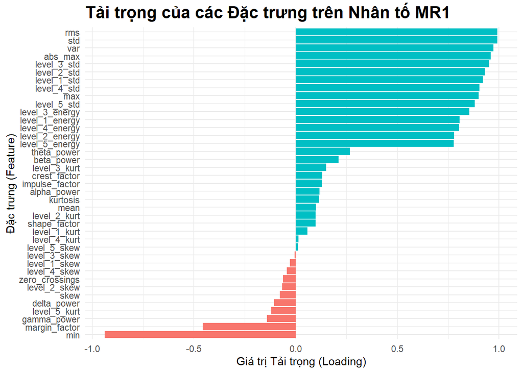

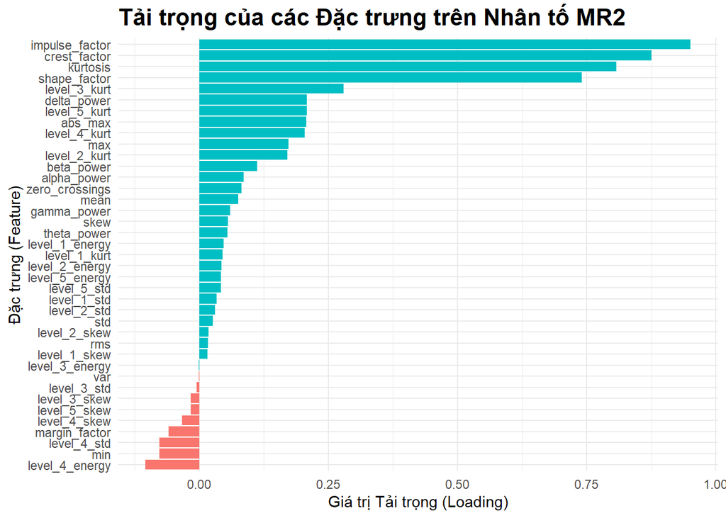

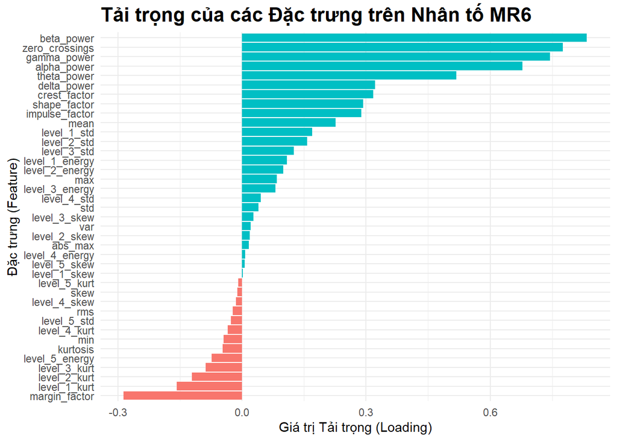

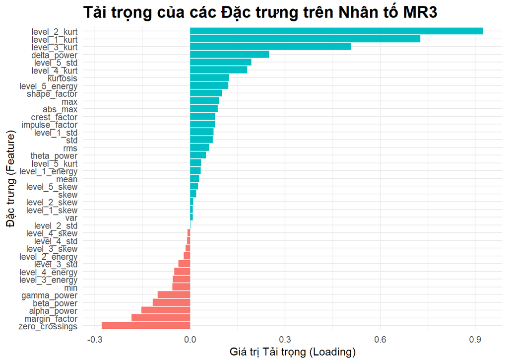

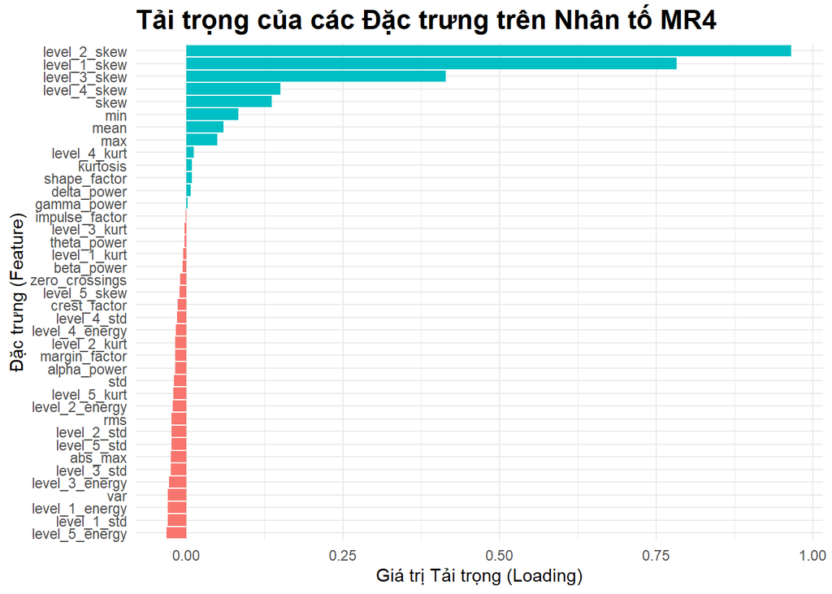

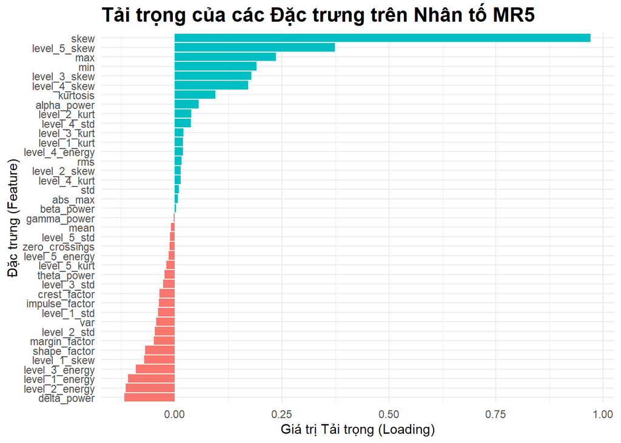

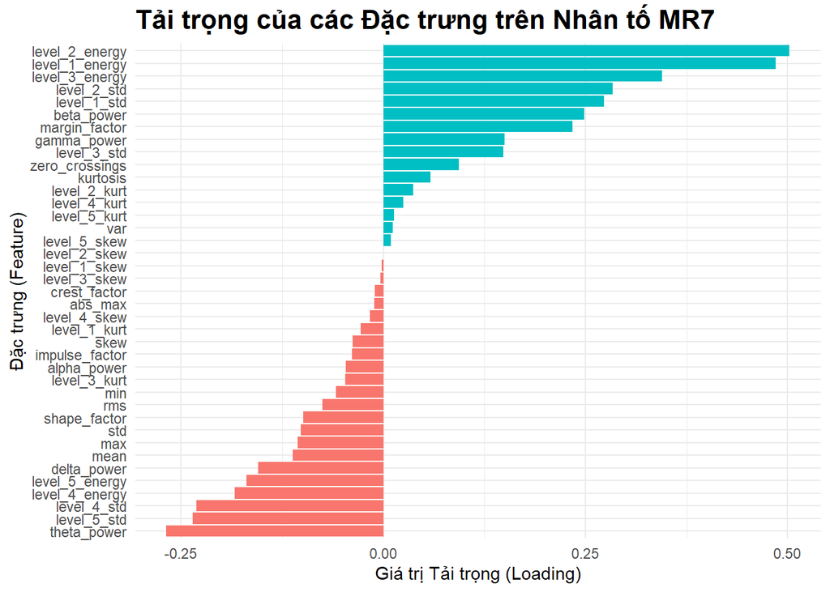

```r
library(tidytext) # Cần cho việc sắp xếp trong mỗi panel
# Lấy ma trận tải trọng và chuyển sang dạng dài (giữ nguyên)
loadings_matrix <- fa_result$loadings
loadings_long <- as.data.frame(loadings_matrix[,]) %>%
  mutate(feature = rownames(.)) %>%
  pivot_longer(
    cols = -feature,
    names_to = "factor",
    values_to = "loading"
  )

# Lặp qua từng nhân tố (factor) để vẽ và in ra biểu đồ riêng biệt
factor_names <- unique(loadings_long$factor)

for (factor_name in factor_names) {

  # Lọc dữ liệu chỉ cho nhân tố hiện tại
  plot_data <- loadings_long %>%
    filter(factor == factor_name)

  # Tạo biểu đồ cho nhân tố hiện tại
  p <- ggplot(plot_data, aes(y = loading,
                             x = reorder(feature, loading),
                             fill = loading > 0)) + # Tô màu khác nhau cho giá trị âm/dương
    geom_col(show.legend = FALSE) +
    coord_flip() + # Lật trục để dễ đọc tên đặc trưng
    labs(
      title = paste("Tải trọng của các Đặc trưng trên Nhân tố", factor_name), # Tiêu đề động
      x = "Đặc trưng (Feature)",
      y = "Giá trị Tải trọng (Loading)"
    ) +
    theme_minimal() +
    theme(
      plot.title = element_text(size = 16, face = "bold")
    )

  # In biểu đồ ra output
  print(p)
}
```

Ta vẽ MR1 và MR2 biểu thị cho giải thích khoarngf4 49% phương sai.

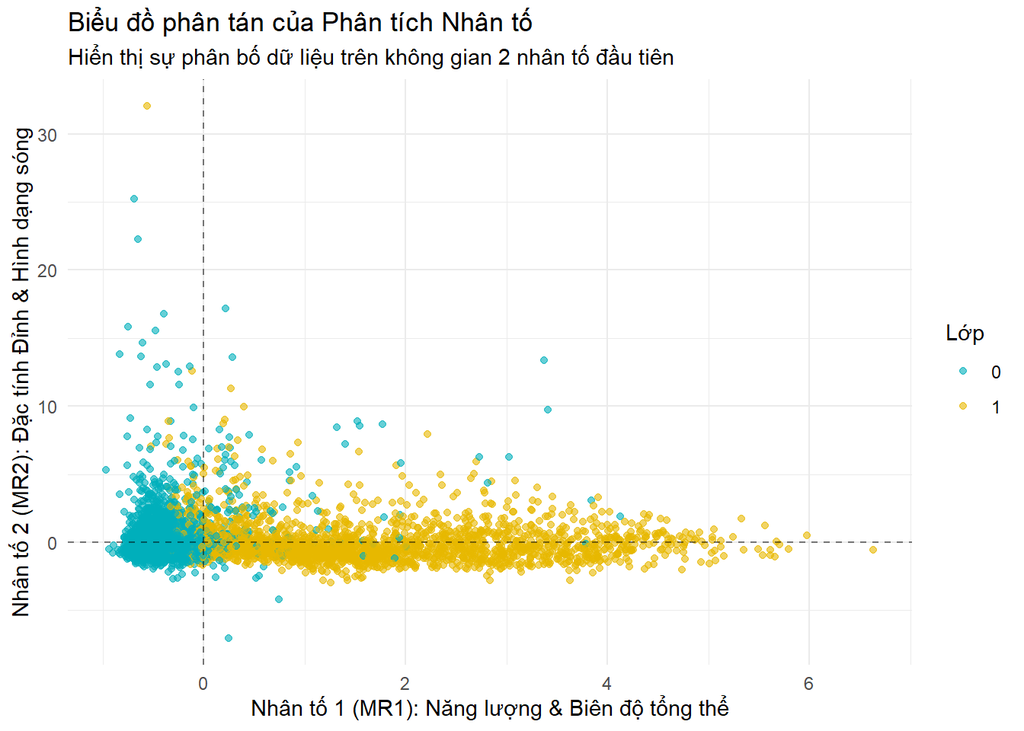

```r
# Trích xuất điểm số nhân tố (Factor Scores)
factor_scores <- as.data.frame(fa_result$scores)

# Kết hợp điểm số với nhãn lớp để vẽ biểu đồ
fa_data_for_plot <- bind_cols(factor_scores, Class = y_labels_factor)

# Vẽ biểu đồ phân tán
# Chúng ta sẽ vẽ 2 nhân tố đầu tiên: MR1 và MR2
ggplot(fa_data_for_plot, aes(x = MR1, y = MR2, color = Class)) +
  geom_point(alpha = 0.6) +
  labs(
    title = "Biểu đồ phân tán của Phân tích Nhân tố",
    subtitle = "Hiển thị sự phân bố dữ liệu trên không gian 2 nhân tố đầu tiên",
    x = "Nhân tố 1 (MR1): Năng lượng & Biên độ tổng thể", # Diễn giải từ file .Rmd của bạn
    y = "Nhân tố 2 (MR2): Đặc tính Đỉnh & Hình dạng sóng" # Diễn giải từ file .Rmd của bạn
  ) +
  theme_minimal() +
  scale_color_manual(values = c("0" = "#00AFBB", "1" = "#E7B800"), name = "Lớp") +
  # Thêm đường kẻ x=0 và y=0 để làm rõ các góc phần tư
  geom_hline(yintercept = 0, linetype = "dashed", alpha = 0.5) +
  geom_vline(xintercept = 0, linetype = "dashed", alpha = 0.5)
```

## 4.3. Phân tích Phương sai Đa biến (MANOVA)

Chúng ta sẽ sử dụng MANOVA để kiểm tra xem có sự khác biệt thống kê giữa vector trung bình của các đặc trưng trong hai nhóm “co giật” và “không co giật” hay không.

### 4.3.1 Kiểm định giả thuyết MANOVA

Trức khi kiểm định MANOVA, chúng ta cần kiểm tra hai giả định quan trọng.

1. *Giả định về tính đồng nhất của ma trận hiệp phương sai*

Chúng ta sử dụng kiểm định Box’s M để kiểm tra xem ma trận hiệp phương sai của các đặc trưng có đồng nhất giữa hai nhóm hay không.

- $H_0:$ Các ma trận hiệp phương sai của các nhóm là bằng nhau
- $H_a:$ Có ít nhất một ma trận hiệp phương sai là khác biệt.

```r
boxm_result <- boxM(data = X_features_scaled, grouping = y_labels_factor)
print(boxm_result)
```

```
##
##  Box's M-test for Homogeneity of Covariance Matrices
##
## data:  X_features_scaled
## Chi-Sq (approx.) = 338245, df = 780, p-value < 2.2e-16
```

2. *Giả định về tính chuẩn đa biến*

Với cỡ mẫu lớn, kiểm định Shapiro-Wilk không còn phù hợp do quá nhạy. Thay vào đó, chúng ta sử dụng Henze-Zirkler’s test – một kiểm định thống kê bền vững hơn, phù hợp cho dữ liệu đa biến với cỡ mẫu lớn.

- $H_0:$ Dữ liệu tuân theo phân phối chuẩn đa biến
- $H_a:$ Dữ liệu không tuân theo phân phối chuẩn đa biến

```r
library(MVN)

# Chạy và xem kết quả được in trực tiếp ra Console
cat("--- Kết quả kiểm định chuẩn đa biến cho nhóm Non-Seizure (0) ---\n")
```

```
## --- Kết quả kiểm định chuẩn đa biến cho nhóm Non-Seizure (0) ---
```

```r
MVN::mvn(data = X_features_scaled[y_labels_factor == "0", ])
```

```
## $multivariate_normality
##            Test Statistic p.value     Method          MVN
## 1 Henze-Zirkler     1.209  <0.001 asymptotic ✗ Not normal
##
## $univariate_normality
##                Test       Variable Statistic p.value    Normality
## 1  Anderson-Darling           mean    67.494  <0.001 ✗ Not normal
## 2  Anderson-Darling            std   575.164  <0.001 ✗ Not normal
## 3  Anderson-Darling            var  2175.739  <0.001 ✗ Not normal
## 4  Anderson-Darling            min   215.607  <0.001 ✗ Not normal
## 5  Anderson-Darling            max   811.292  <0.001 ✗ Not normal
## 6  Anderson-Darling           skew    96.762  <0.001 ✗ Not normal
## 7  Anderson-Darling       kurtosis   686.446  <0.001 ✗ Not normal
## 8  Anderson-Darling            rms   452.314  <0.001 ✗ Not normal
## 9  Anderson-Darling zero_crossings    29.226  <0.001 ✗ Not normal
```

[output cut: 143 more lines]

```r
cat("\n--- Kết quả kiểm định chuẩn đa biến cho nhóm Seizure (1) ---\n")
```

```
##
## --- Kết quả kiểm định chuẩn đa biến cho nhóm Seizure (1) ---
```

```r
MVN::mvn(data = X_features_scaled[y_labels_factor == "1", ])
```

```
## $multivariate_normality
##            Test Statistic p.value     Method          MVN
## 1 Henze-Zirkler     1.098  <0.001 asymptotic ✗ Not normal
##
## $univariate_normality
##                Test       Variable Statistic p.value    Normality
## 1  Anderson-Darling           mean     5.023  <0.001 ✗ Not normal
## 2  Anderson-Darling            std    36.447  <0.001 ✗ Not normal
## 3  Anderson-Darling            var   109.369  <0.001 ✗ Not normal
## 4  Anderson-Darling            min    93.503  <0.001 ✗ Not normal
## 5  Anderson-Darling            max    30.761  <0.001 ✗ Not normal
## 6  Anderson-Darling           skew     2.515  <0.001 ✗ Not normal
## 7  Anderson-Darling       kurtosis    96.975  <0.001 ✗ Not normal
## 8  Anderson-Darling            rms    38.038  <0.001 ✗ Not normal
## 9  Anderson-Darling zero_crossings    24.699  <0.001 ✗ Not normal
```

[output cut: 143 more lines]

**Nhận xét:** Kết quả từ kiểm định Henze-Zirkler cho thấy p-value của cả hai nhóm đều rất nhỏ (p < 0.001), do đó chúng ta bác bỏ giả thuyết $H_0$ và kết luận rằng dữ liệu **không tuân theo phân phối chuẩn đa biến**.

### 4.3.2. Thực hiện kiểm định MANOVA

Các giả thuyết thống kê cho phép kiểm định này là:

- **$H_0$**: Không có sự khác biệt có ý nghĩa thống kê về vector trung bình giữa hai nhóm: $\mu_{\text{co\_giật}} = \mu_{\text{không\_co\_giật}}$
- **$H_a$**: Có ít nhất một khác biệt có ý nghĩa thống kê giữa vector trung bình hai nhóm: $\mu_{\text{co\_giật}} \ne \mu_{\text{không\_co\_giật}}$

```r
# Thực hiện MANOVA
manova_result <- manova(as.matrix(X_features_scaled) ~ y_labels_factor)
summary(manova_result, test = "Wilks")
```

```
##                    Df   Wilks approx F num Df den Df    Pr(>F)
## y_labels_factor     1 0.19115   1243.4     39  11460 < 2.2e-16 ***
## Residuals       11498
## ---
## Signif. codes:  0 '***' 0.001 '**' 0.01 '*' 0.05 '.' 0.1 ' ' 1
```

Phát hiện này khẳng định rằng bộ đặc trưng đã trích xuất **có khả năng phân biệt mạnh mẽ giữa nhóm co giật và không co giật**, cho thấy tiềm năng sử dụng trong phân tích hoặc mô hình phân loại sau này.

# V. Phương pháp Trực quan Phi tuyến

Sau khi khám phá dữ liệu bằng các phương pháp tuyến tính như PCA và Phân tích Nhân tố (FA), chúng ta nhận thấy rằng mặc dù có sự khác biệt giữa hai lớp, vẫn tồn tại vùng chồng lấn đáng kể. Điều này gợi ý rằng ranh giới phân tách giữa hai trạng thái “co giật” và “không co giật” có thể không đơn thuần là tuyến tính.

Để có được cái nhìn rõ nét hơn về cấu trúc phân cụm trong dữ liệu, chúng ta sử dụng hai phương pháp giảm chiều phi tuyến phổ biến: **t-SNE** và **UMAP**. Cả hai đều nổi bật trong việc ánh xạ dữ liệu từ không gian nhiều chiều xuống không gian 2D, đồng thời bảo toàn cấu trúc “lân cận” giữa các điểm dữ liệu – tức là đưa các điểm tương tự nhau lại gần nhau trên biểu đồ, từ đó giúp làm nổi bật các cụm tiềm ẩn trong dữ liệu.

## 5.1. Trực quan hóa bằng t-SNE và UMAP

t-SNE và UMAP là các kỹ thuật mạnh mẽ để trực quan hóa dữ liệu nhiều chiều trong không gian 2D.

```r
# Đặt seed để kết quả của t-SNE và UMAP có thể tái lập
set.seed(42)

# t-SNE trên toàn bộ dữ liệu
cat("Đang chạy t-SNE trên toàn bộ 11,500 điểm dữ liệu...\n")
```

```
## Đang chạy t-SNE trên toàn bộ 11,500 điểm dữ liệu...
```

```r
tsne_out <- Rtsne(X_features_scaled, dims = 2, perplexity = 30, verbose = FALSE, max_iter = 500)
df_tsne <- tibble(Dim1 = tsne_out$Y[,1], Dim2 = tsne_out$Y[,2], Class = y_labels_factor)
p_tsne <- ggplot(df_tsne, aes(x = Dim1, y = Dim2, color = Class)) +
  geom_point(alpha = 0.7) +
  labs(title = "t-SNE trên toàn bộ dữ liệu") +
  theme_minimal()

# UMAP trên toàn bộ dữ liệu
cat("Đang chạy UMAP trên toàn bộ 11,500 điểm dữ liệu...\n")
```

```
## Đang chạy UMAP trên toàn bộ 11,500 điểm dữ liệu...
```

```r
umap_out <- uwot::umap(X_features_scaled, n_neighbors = 15, min_dist = 0.1, n_components = 2)
df_umap <- tibble(Dim1 = umap_out[,1], Dim2 = umap_out[,2], Class = y_labels_factor)
p_umap <- ggplot(df_umap, aes(x = Dim1, y = Dim2, color = Class)) +
  geom_point(alpha = 0.7) +
  labs(title = "UMAP trên toàn bộ dữ liệu") +
  theme_minimal()

# So sánh kết quả
cat("Đang vẽ biểu đồ...\n")
```

```
## Đang vẽ biểu đồ...
```

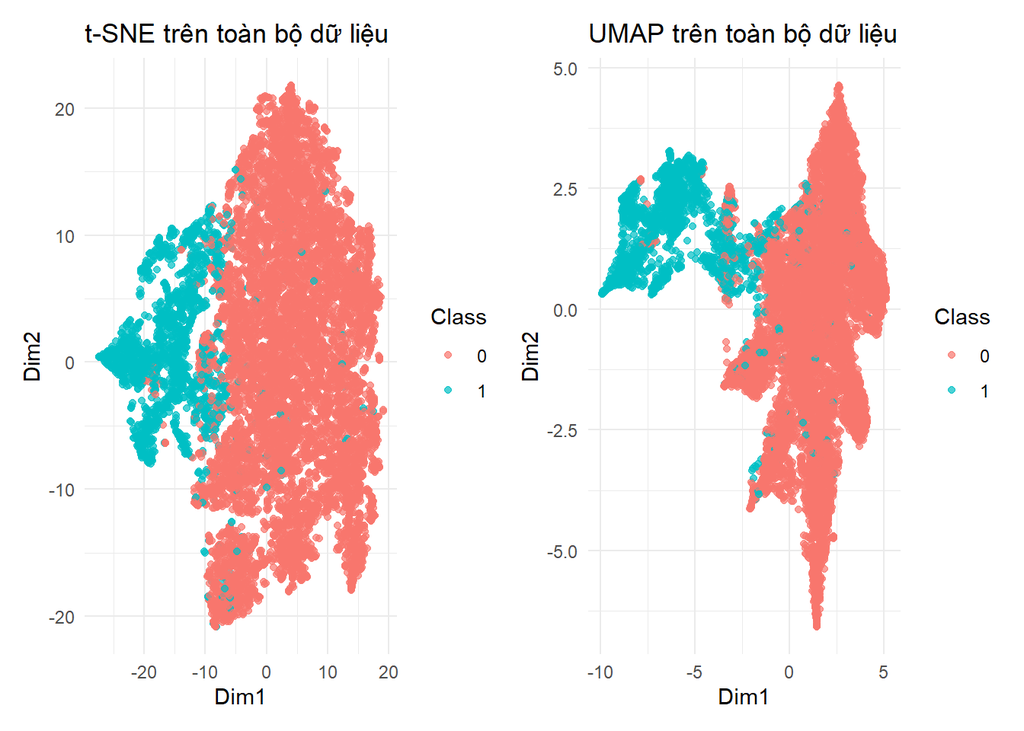

```r
p_tsne + p_umap
```

**Nhận xét:** Cả hai biểu đồ đều thể hiện sự phân tách rõ ràng giữa hai nhóm dữ liệu. Các điểm thuộc nhóm “Seizure” và “Non-Seizure” hình thành nên hai cụm gần như riêng biệt, với rất ít điểm bị chồng lấn. Trong đó, UMAP cho thấy khả năng bảo toàn cấu trúc toàn cục tốt hơn so với t-SNE. Kết quả này củng cố giả thuyết rằng bộ đặc trưng hiện tại có **khả năng phân biệt mạnh mẽ** giữa hai trạng thái.

## 5.2. So sánh với PCA và FA

Việc so sánh các phương pháp giảm chiều như PCA, FA, t-SNE và UMAP cho thấy mỗi kỹ thuật phản ánh một khía cạnh khác nhau của cấu trúc dữ liệu khi chiếu xuống không gian thấp chiều.

- **PCA (Phân tích Thành phần Chính):**
  - Giữ lại phần lớn phương sai của dữ liệu (56.7% trong hai thành phần đầu).
  - Dễ nhận thấy sự khác biệt giữa hai lớp theo trục thành phần thứ nhất.
  - Tuy nhiên, vẫn có sự chồng lấn đáng kể giữa hai lớp, do đây là phương pháp tuyến tính.
- **FA (Phân tích Nhân tố):**
  - Hữu ích trong việc phát hiện các cấu trúc nhân tố tiềm ẩn.
  - Tuy nhiên, trên biểu đồ 2D, khả năng phân tách giữa các lớp không cải thiện nhiều so với PCA.
- **t-SNE và UMAP:**
  - Là các kỹ thuật phi tuyến, không cố gắng giữ lại phương sai toàn cục mà tập trung vào việc bảo toàn cấu trúc lân cận.
  - Cả hai đều cho thấy sự phân cụm rõ ràng và gần như tách biệt hoàn toàn giữa hai lớp trong không gian 2D.

**Kết luận:**

Kết quả từ t-SNE và UMAP cho thấy cấu trúc phân lớp trong dữ liệu **không hoàn toàn tuyến tính** – điều mà các phương pháp như PCA hay FA không thể hiện rõ. Tuy nhiên, **các đặc trưng được giữ lại qua PCA vẫn chứa đủ thông tin** để mô hình học máy có thể khai thác được ranh giới phân loại, kể cả khi nó phi tuyến.

# VI. Mô hình Phân loại

Trong phần này, chúng ta sẽ xây dựng và so sánh hiệu năng của các mô hình học máy dự trên data với bộ đặc trưng đây dủ và đã qua xử lý pca.

## 6.1 Chuẩn bị dữ liệu huấn luyện

```r
# Phân chia dữ liệu và chuẩn bị
set.seed(42)
trainIndex <- createDataPartition(y_labels_factor, p = 0.8, list = FALSE)

train_features <- X_features_filtered[trainIndex, ]
test_features  <- X_features_filtered[-trainIndex, ]

y_train <- y_labels_factor[trainIndex]
y_test  <- y_labels_factor[-trainIndex]

# Đổi tên các mức của biến mục tiêu để tương thích với caret
levels(y_train)[levels(y_train)=="0"] <- "NonSeizure"
levels(y_train)[levels(y_train)=="1"] <- "Seizure"
levels(y_test)[levels(y_test)=="0"] <- "NonSeizure"
levels(y_test)[levels(y_test)=="1"] <- "Seizure"

# Tạo data frame huấn luyện hoàn chỉnh chứa cả đặc trưng và nhãn
train_df <- train_features %>%
  mutate(y = y_train)
```

```r
# Kiểm tra phân bố lớp trên tập huấn luyện ban đầu
cat("--- Phân bố lớp trên tập huấn luyện ---\n")
```

```
## --- Phân bố lớp trên tập huấn luyện ---
```

```r
print(prop.table(table(y_train)))
```

```
## y_train
## NonSeizure    Seizure
##        0.8        0.2
```

**Nhận xét:** Kết quả phân tích cho thấy lớp ‘0’ (Non-Seizure) chiếm khoảng 80% tổng số quan sát, trong khi lớp ‘1’ (Seizure) chỉ chiếm khoảng 20%. Đây là một tình trạng **mất cân bằng dữ liệu nghiêm trọng**, có thể dẫn đến việc mô hình bị thiên lệch trong quá trình huấn luyện: dễ dự đoán chính xác lớp đa số nhưng **kém hiệu quả khi nhận diện các trường hợp Seizure – vốn là mục tiêu chính trong bối cảnh lâm sàng**.

Để khắc phục vấn đề này, chúng tôi đã áp dụng kỹ thuật **SMOTE (Synthetic Minority Over-sampling Technique)** nhằm **tăng cường mẫu cho lớp thiểu số bằng cách tạo ra các điểm dữ liệu tổng hợp** từ các trường hợp hiện có. Việc này giúp cân bằng phân bố giữa hai lớp, góp phần cải thiện khả năng học của mô hình và nâng cao độ nhạy trong việc phát hiện các trường hợp co giật.

## 6.2 Huấn luyện với kiểm định chéo

```r
# Thiết lập control cho quá trình huấn luyện
train_control <- trainControl(
  method = "cv",
  number = 10,
  classProbs = TRUE,                 # Cần thiết để tính ROC-AUC
  summaryFunction = twoClassSummary, # Báo cáo các chỉ số ROC, Sensitivity, Specificity
  verboseIter = TRUE                 # Hiển thị tiến trình huấn luyện để theo dõi
)
```

```r
# Chuẩn bị để lưu trữ và so sánh các mô hình
models_to_compare <- list()
model_list <- list(LDA = "lda", SVM = "svmRadial", RF = "rf")

# Định nghĩa recipe cho bộ đặc trưng đầy đủ
full_recipe <- recipe(y ~ ., data = train_df) %>%
  step_center(all_predictors()) %>%
  step_scale(all_predictors()) %>%
  step_smote(y, over_ratio = 1, seed = 123)

# Huấn luyện các mô hình
for (model_name in names(model_list)) {
  set.seed(42)
  models_to_compare[[model_name]] <- train(
    full_recipe,
    data = train_df,
    method = model_list[[model_name]],
    trControl = train_control,
    metric = "ROC",
    tuneLength = 3
  )
}
```

```
## Preparing recipe
```

```
## Preparing recipe
```

```
## Preparing recipe
```

```r
# So sánh kết quả từ kiểm định chéo
algorithm_comparison <- resamples(models_to_compare)
summary(algorithm_comparison)
```

```
##
## Call:
## summary.resamples(object = algorithm_comparison)
##
## Models: LDA, SVM, RF
## Number of resamples: 10
##
## ROC
##          Min.   1st Qu.    Median      Mean   3rd Qu.      Max. NA's
## LDA 0.9848845 0.9892910 0.9932250 0.9923079 0.9955012 0.9973121    0
## SVM 0.9966919 0.9971386 0.9983939 0.9980388 0.9986007 0.9991804    0
## RF  0.9946612 0.9972328 0.9978752 0.9976249 0.9989957 0.9991397    0
##
## Sens
##          Min.   1st Qu.    Median      Mean   3rd Qu.      Max. NA's
## LDA 0.9701087 0.9758832 0.9782609 0.9792120 0.9816576 0.9904891    0
## SVM 0.9836957 0.9864130 0.9891304 0.9883152 0.9904891 0.9918478    0
## RF  0.9782609 0.9813179 0.9850543 0.9845109 0.9874321 0.9918478    0
##
## Spec
##          Min.   1st Qu.    Median      Mean   3rd Qu.      Max. NA's
## LDA 0.9130435 0.9211957 0.9402174 0.9358696 0.9442935 0.9619565    0
## SVM 0.9402174 0.9551630 0.9728261 0.9679348 0.9823370 0.9891304    0
## RF  0.9456522 0.9687500 0.9755435 0.9722826 0.9782609 0.9891304    0
```

**Phân tích Hiệu năng và Lựa chọn Mô hình**

| Mô hình | ROC (TB) | Sensitivity | Specificity |
| --- | --- | --- | --- |
| LDA | 0.9923 | 0.9792 | 0.9359 |
| **SVM** | **0.9980** | **0.9883** | 0.9679 |
| RF | 0.9976 | 0.9845 | **0.9723** |

**Nhận xét chính**

- **SVM** có **ROC và Sensitivity cao nhất**, cho thấy khả năng phân loại tốt và đặc biệt hiệu quả trong việc **phát hiện đúng các ca bệnh thực sự** (giảm nguy cơ bỏ sót bệnh nhân – False Negative).
- **RF** đạt **Specificity cao nhất**, tức mô hình này **giỏi hơn trong việc loại trừ các ca không mắc bệnh**, giúp giảm báo động giả (False Positive), dù ROC và Sensitivity kém hơn SVM một chút.
- **LDA** có hiệu năng thấp hơn rõ ở cả ba chỉ số, nên không phù hợp cho ứng dụng lâm sàng.

Để có cái nhìn trực quan hơn về sự khác biệt và độ ổn định của các mô hình, chúng ta có thể vẽ biểu đồ `dénityplot` và `dotplot` so sánh chỉ số ROC-AUC thu được.

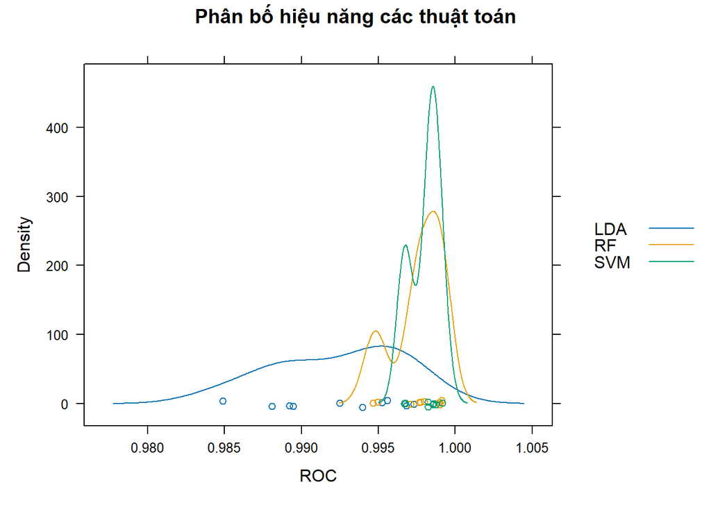

```r
densityplot(algorithm_comparison, metric = "ROC", auto.key = TRUE,
            main = "Phân bố hiệu năng các thuật toán")
```

**Nhận xét:**

- **SVM (xanh lá):** Phân bố hẹp, đỉnh cao, tập trung quanh 0.998–0.999 → hiệu năng cao và ổn định nhất.
- **RF (vàng):** Phân bố khá tập trung, lệch nhẹ về trái so với SVM → hiệu năng tốt, độ ổn định kém hơn SVM.
- **LDA (xanh dương):** Phân bố rộng, thấp hơn rõ → hiệu năng thấp và không ổn định.

Biểu đồ hiển thị giá trị ROC trung bình kèm khoảng tin cậy 95% cho từng thuật toán.

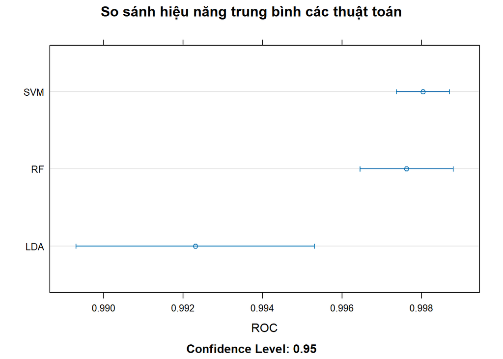

```r
dotplot(algorithm_comparison, metric = "ROC", main = "So sánh hiệu năng trung bình các thuật toán")
```

**Nhận xét:**

**Kết luận:** Từ các kết quả trên, SVM là mô hình có hiệu năng ổn định và vượt trội nhất, nên ta sẽ chọn SVM để đánh giá trên dữ liệu đã qua PCA.

## 6.3 Huấn luyện trên dữ liệu đã qua PCA

Sau khi xác định SVM là mô hình tốt nhất trên bộ đặc trưng đầy đủ, chúng ta sẽ kiểm tra xem việc giảm chiều bằng PCA có phải là một sự đánh đổi hiệu quả hay không. Chúng ta sẽ so sánh hiệu năng của mô hình SVM trên bộ đặc trưng đầy đủ so với các phiên bản SVM được huấn luyện trên dữ liệu đã giảm chiều.

```r
# Lấy mô hình SVM đã được huấn luyện trên dữ liệu đầy đủ
svm_full_model <- models_to_compare[["SVM"]]

# Chuẩn bị danh sách để so sánh SVM_Full và các phiên bản SVM_PCA
pca_comparison_list <- list(SVM_Full = svm_full_model)

# Vòng lặp qua các kịch bản PCA
for (n_components in c(12, 9, 4)) {
  # Cập nhật thông báo
  cat(paste("\n--- Đang huấn luyện SVM với", n_components, "thành phần chính... ---\n"))

  # Tạo recipe với bước PCA (giữ nguyên)
  pca_recipe <- recipe(y ~ ., data = train_df) %>%
    step_center(all_predictors()) %>%
    step_scale(all_predictors()) %>%
    step_pca(all_predictors(), num_comp = n_components) %>%
    step_smote(y, over_ratio = 1, seed = 123)

  set.seed(42)
  # Huấn luyện chỉ mô hình SVM
  pca_comparison_list[[paste0("SVM_", n_components, "PCA")]] <- train(
    pca_recipe,
    data = train_df,
    method = "svmRadial", # <-- THAY ĐỔI 1: Đổi phương thức thành "svmRadial"
    trControl = train_control,
    metric = "ROC",
    # Tối ưu: Sử dụng lại tham số đã tinh chỉnh của mô hình SVM tốt nhất
    tuneGrid = svm_full_model$bestTune # <-- THAY ĐỔI 2: Lấy bestTune từ mô hình SVM
  )
}
```

```
##
## --- Đang huấn luyện SVM với 12 thành phần chính... ---
## Preparing recipe
##
## --- Đang huấn luyện SVM với 9 thành phần chính... ---
## Preparing recipe
##
## --- Đang huấn luyện SVM với 4 thành phần chính... ---
## Preparing recipe
```

```r
# So sánh kết quả của các phiên bản SVM
svm_pca_comparison <- resamples(pca_comparison_list)
summary(svm_pca_comparison)
```

```
##
## Call:
## summary.resamples(object = svm_pca_comparison)
##
## Models: SVM_Full, SVM_12PCA, SVM_9PCA, SVM_4PCA
## Number of resamples: 10
##
## ROC
##                Min.   1st Qu.    Median      Mean   3rd Qu.      Max. NA's
## SVM_Full  0.9966919 0.9971386 0.9983939 0.9980388 0.9986007 0.9991804    0
## SVM_12PCA 0.9894480 0.9940299 0.9958242 0.9951131 0.9972512 0.9977404    0
## SVM_9PCA  0.9911168 0.9924496 0.9948975 0.9945748 0.9968229 0.9974155    0
## SVM_4PCA  0.9857042 0.9909580 0.9937825 0.9925862 0.9950175 0.9972014    0
##
## Sens
##                Min.   1st Qu.    Median      Mean   3rd Qu.      Max. NA's
## SVM_Full  0.9836957 0.9864130 0.9891304 0.9883152 0.9904891 0.9918478    0
## SVM_12PCA 0.9714674 0.9769022 0.9796196 0.9794837 0.9806386 0.9891304    0
## SVM_9PCA  0.9660326 0.9714674 0.9735054 0.9750000 0.9809783 0.9823370    0
## SVM_4PCA  0.9605978 0.9646739 0.9687500 0.9694293 0.9748641 0.9823370    0
##
## Spec
##                Min.   1st Qu.    Median      Mean   3rd Qu.      Max. NA's
## SVM_Full  0.9402174 0.9551630 0.9728261 0.9679348 0.9823370 0.9891304    0
## SVM_12PCA 0.9293478 0.9524457 0.9646739 0.9614130 0.9714674 0.9782609    0
## SVM_9PCA  0.9402174 0.9524457 0.9592391 0.9570652 0.9619565 0.9782609    0
## SVM_4PCA  0.9347826 0.9510870 0.9565217 0.9559783 0.9605978 0.9782609    0
```

**So sánh hiệu năng SVM với và không dùng PCA**

| Mô hình | ROC (TB) | Sensitivity | Specificity |
| --- | --- | --- | --- |
| **SVM_Full** | **0.9980** | **0.9883** | **0.9679** |
| SVM_12PCA | 0.9951 | 0.9795 | 0.9614 |
| SVM_9PCA | 0.9946 | 0.9750 | 0.9571 |
| SVM_4PCA | 0.9926 | 0.9694 | 0.9560 |

**Nhận xét:**

- **SVM_Full** cho hiệu năng cao nhất, cho thấy việc giữ nguyên toàn bộ đặc trưng mang lại kết quả tối ưu.
- Khi số chiều giảm dần qua PCA, hiệu năng có xu hướng giảm theo, đặc biệt rõ ở chỉ số ROC và Sensitivity.
- Tuy nhiên, các phiên bản như **SVM_12PCA hoặc SVM_9PCA vẫn duy trì hiệu năng ở mức cao**, với ROC trên 0.994 và Sensitivity trên 0.97 → cho thấy kết quả **vẫn đủ mạnh để được xem là chấp nhận được trong nhiều tình huống ứng dụng thực tế**.

**Tác động của PCA đến hiệu năng và tính chấp nhận được**

- PCA giúp giảm số chiều đầu vào, từ đó **rút ngắn thời gian huấn luyện**, **giảm tài nguyên tính toán**, và **hạn chế quá khớp** khi số đặc trưng ban đầu lớn.
- Dù hiệu năng có giảm nhẹ, các mô hình PCA vẫn cho kết quả tương đối ổn định và có thể **đủ tốt cho các hệ thống triển khai thực tế cần tốc độ và hiệu quả cao hơn**.
- Như vậy, PCA là **một sự đánh đổi hợp lý** giữa độ chính xác và hiệu suất tính toán, nhất là khi mô hình được tích hợp vào các hệ thống thời gian thực hoặc tài nguyên hạn chế.

**Kết luận**

- Nếu mục tiêu ưu tiên là độ chính xác tuyệt đối trong môi trường yêu cầu cao (như y tế), **SVM_Full** vẫn là lựa chọn tốt nhất.
- Tuy nhiên, các phiên bản **SVM_PCA với 9–12 thành phần chính** hoàn toàn có thể **được chấp nhận** trong các tình huống thực tế, khi hiệu năng chỉ giảm nhẹ nhưng mô hình trở nên nhẹ hơn, nhanh hơn và dễ triển khai hơn.

$\Rightarrow$ Do đó, PCA là lựa chọn khả thi trong thực hành nếu cần cân bằng giữa độ chính xác và hiệu suất tính toán.

## 6.4 Đánh giá trên tập kiểm tra

Dựa trên các phân tích trước đó, hai mô hình tiềm năng nhất được lựa chọn là SVM_Full (có hiệu năng cao nhất) và SVM_12PCA (đạt được sự cân bằng hợp lý giữa hiệu năng và độ phức tạp mô hình). Trong phần này, chúng tôi sẽ tiến hành đánh giá cả hai mô hình trên tập dữ liệu kiểm tra nhằm đưa ra quyết định lựa chọn cuối cùng.

Đánh giá model `SVM_full`

```r
# Lấy mô hình SVM_Full từ danh sách so sánh
model_full <- pca_comparison_list[["SVM_Full"]]

# Dự đoán trên tập kiểm tra
predictions_full <- predict(model_full, newdata = test_features)

# Tạo ma trận nhầm lẫn
cat("--- Kết quả của mô hình SVM_Full trên tập Test ---\n")
```

```
## --- Kết quả của mô hình SVM_Full trên tập Test ---
```

```r
cm_full <- confusionMatrix(data = predictions_full, reference = y_test, positive = "Seizure")
print(cm_full)
```

```
## Confusion Matrix and Statistics
##
##             Reference
## Prediction   NonSeizure Seizure
##   NonSeizure       1827      13
##   Seizure            13     447
##
##                Accuracy : 0.9887
##                  95% CI : (0.9835, 0.9926)
##     No Information Rate : 0.8
##     P-Value [Acc > NIR] : <2e-16
##
##                   Kappa : 0.9647
##
##  Mcnemar's Test P-Value : 1
##
##             Sensitivity : 0.9717
##             Specificity : 0.9929
##          Pos Pred Value : 0.9717
##          Neg Pred Value : 0.9929
##              Prevalence : 0.2000
##          Detection Rate : 0.1943
##    Detection Prevalence : 0.2000
##       Balanced Accuracy : 0.9823
##
##        'Positive' Class : Seizure
##
```

**Hiệu năng mô hình SVM_Full trên tập Test**

|  | Dự đoán: NonSeizure | Dự đoán: Seizure |
| --- | --- | --- |
| **Thực tế: NonSeizure** | 1827 | 13 |
| **Thực tế: Seizure** | 13 | 447 |

**Nhận xét:**

- **Độ chính xác tổng thể (Accuracy):** Đạt **98.87%** với khoảng tin cậy 95% là **(98.35%, 99.26%)** → cho thấy mô hình hoạt động ổn định và đáng tin cậy.
- **Độ nhạy (Sensitivity – phát hiện Seizure):** **97.17%** → mô hình phát hiện đúng phần lớn các trường hợp thực sự bị động kinh, giảm thiểu nguy cơ bỏ sót bệnh nhân.
- **Độ đặc hiệu (Specificity – nhận diện NonSeizure):** **99.29%** → mô hình rất chính xác trong việc xác định người không bị bệnh, giúp hạn chế báo động giả.
- **Chỉ số Kappa:** **0.9647** → phản ánh mức độ đồng thuận rất cao giữa dự đoán và thực tế, vượt xa mức ngẫu nhiên.
- **Balanced Accuracy:** **98.23%** → trung bình giữa Sensitivity và Specificity, phù hợp khi dữ liệu mất cân bằng.
- **McNemar’s Test p-value = 1:** Cho thấy không có sự bất đối xứng đáng kể giữa hai loại lỗi (False Positive và False Negative) → dự đoán hai chiều cân bằng.

Đánh giá mô hình `SVM_12PCA`

```r
# Lấy mô hình SVM_12PCA từ danh sách so sánh
model_pca12 <- pca_comparison_list[["SVM_12PCA"]]

# Dự đoán trên tập kiểm tra
predictions_pca12 <- predict(model_pca12, newdata = test_features)

# Tạo ma trận nhầm lẫn
cat("\n--- Kết quả của mô hình SVM_12PCA trên tập Test ---\n")
```

```
##
## --- Kết quả của mô hình SVM_12PCA trên tập Test ---
```

```r
cm_pca12 <- confusionMatrix(data = predictions_pca12, reference = y_test, positive = "Seizure")
print(cm_pca12)
```

```
## Confusion Matrix and Statistics
##
##             Reference
## Prediction   NonSeizure Seizure
##   NonSeizure       1812      21
##   Seizure            28     439
##
##                Accuracy : 0.9787
##                  95% CI : (0.9719, 0.9842)
##     No Information Rate : 0.8
##     P-Value [Acc > NIR] : <2e-16
##
##                   Kappa : 0.9338
##
##  Mcnemar's Test P-Value : 0.3914
##
##             Sensitivity : 0.9543
##             Specificity : 0.9848
##          Pos Pred Value : 0.9400
##          Neg Pred Value : 0.9885
##              Prevalence : 0.2000
##          Detection Rate : 0.1909
##    Detection Prevalence : 0.2030
##       Balanced Accuracy : 0.9696
##
##        'Positive' Class : Seizure
##
```

**Hiệu năng mô hình SVM_12PCA trên tập Test**

[output not shown]

**Nhận xét:**

- **Accuracy:** Mô hình đạt độ chính xác **97.87%** (CI 95%: 97.19% – 98.42%) → vẫn ở mức rất cao và đáng tin cậy.
- **Sensitivity (phát hiện Seizure):** **95.43%** → mô hình phát hiện tốt phần lớn ca bệnh, tuy có giảm nhẹ so với SVM_Full (97.17%).
- **Specificity (phân biệt NonSeizure):** **98.48%** → vẫn giữ độ đặc hiệu rất cao, chỉ giảm khoảng 0.8% so với SVM_Full.
- **Kappa = 0.9338:** Thể hiện độ phù hợp cao giữa dự đoán và thực tế, cho thấy mô hình đáng tin cậy.
- **Balanced Accuracy = 96.96%:** Vẫn nằm trong ngưỡng cao, phù hợp với dữ liệu không cân bằng.
- **McNemar’s test p-value = 0.3914:** Không có sự mất cân bằng đáng kể giữa hai loại lỗi → mô hình dự đoán ổn định theo cả hai hướng.

**So sánh nhanh với SVM_Full**

| Chỉ số | SVM_Full | SVM_12PCA |
| --- | --- | --- |
| Accuracy | 98.87% | 97.87% |
| Sensitivity | 97.17% | 95.43% |
| Specificity | 99.29% | 98.48% |
| Kappa | 0.9647 | 0.9338 |

→ **Hiệu năng giảm nhẹ**, nhưng vẫn nằm trong ngưỡng **chấp nhận được**, đặc biệt là khi xét đến lợi ích tính toán từ việc giảm chiều (bộ dữ liệu nhỏ gọn hơn, huấn luyện nhanh hơn).

```r
# Trích xuất các chỉ số từ hai đối tượng confusionMatrix
metrics_summary <- tibble(
  ChiSo = c("Accuracy", "Sensitivity", "Specificity", "F1"),
  SVM_Full = c(
    cm_full$overall['Accuracy'],
    cm_full$byClass['Sensitivity'],
    cm_full$byClass['Specificity'],
    cm_full$byClass['F1']
  ),
  SVM_12PCA = c(
    cm_pca12$overall['Accuracy'],
    cm_pca12$byClass['Sensitivity'],
    cm_pca12$byClass['Specificity'],
    cm_pca12$byClass['F1']
  )
)

# In ra bảng so sánh
knitr::kable(metrics_summary, digits = 4, caption = "So sánh hiệu năng trên tập Test")
```

So sánh hiệu năng trên tập Test

| ChiSo | SVM_Full | SVM_12PCA |
| --- | --- | --- |
| Accuracy | 0.9887 | 0.9787 |
| Sensitivity | 0.9717 | 0.9543 |
| Specificity | 0.9929 | 0.9848 |
| F1 | 0.9717 | 0.9471 |

**So sánh hiệu năng trên tập kiểm tra**

Bảng dưới đây trình bày các chỉ số đánh giá hiệu năng của hai mô hình SVM được lựa chọn, bao gồm: **SVM_Full** (huấn luyện trên toàn bộ tập đặc trưng gốc) và **SVM_12PCA** (huấn luyện trên 12 thành phần chính sau PCA).

| Chỉ số | SVM_Full | SVM_12PCA |
| --- | --- | --- |
| Accuracy | 0.9887 | 0.9787 |
| Sensitivity | 0.9717 | 0.9543 |
| Specificity | 0.9929 | 0.9848 |
| F1-score | 0.9717 | 0.9471 |

**Nhận xét:**

- **SVM_Full vượt trội hơn ở tất cả các chỉ số**, đặc biệt là về Accuracy (0.9887 so với 0.9787) và F1-score (0.9717 so với 0.9471).
- **Độ nhạy (Sensitivity)** và **độ đặc hiệu (Specificity)** của SVM_Full cũng cao hơn, cho thấy mô hình này vừa phát hiện tốt các trường hợp dương tính, vừa hạn chế được báo động giả.
- Tuy nhiên, **SVM_12PCA** vẫn thể hiện hiệu năng khá tốt, trong khi sử dụng số chiều đặc trưng ít hơn đáng kể → phù hợp với các bài toán cần giảm thiểu độ phức tạp mô hình hoặc tài nguyên tính toán.

**Kết luận:** Với mục tiêu tối ưu hiệu năng dự đoán, mô hình **SVM_Full** là lựa chọn phù hợp nhất để triển khai trên tập dữ liệu hiện tại. Tuy nhiên, mô hình **SVM_12PCA** vẫn có thể được cân nhắc trong các tình huống yêu cầu đơn giản hóa mô hình hoặc giảm thiểu chi phí tính toán.

# VII. Kết luận

Nghiên cứu này đã chứng minh rằng từ các đoạn tín hiệu EEG ngắn hạn, hoàn toàn có thể xây dựng một hệ thống tự động nhận diện cơn động kinh với độ chính xác và độ tin cậy cao, mở ra giải pháp khả thi cho việc hỗ trợ chẩn đoán thay thế phương pháp thủ công truyền thống vốn phụ thuộc nhiều vào chuyên gia.

Cốt lõi của hệ thống là quy trình tiền xử lý và trích xuất đặc trưng được thiết kế kỹ lưỡng. Việc khai thác thông tin từ nhiều miền – bao gồm miền thời gian, miền tần số và miền wavelet – đã cho phép làm nổi bật các đặc điểm tín hiệu đặc trưng cho trạng thái co giật, ngay cả khi chúng không dễ nhận biết từ dữ liệu thô. Các phân tích thống kê đa biến (MANOVA) và trực quan hóa phi tuyến (t-SNE, UMAP) đã xác nhận sự phân tách rõ ràng giữa hai trạng thái, cho thấy tiềm năng phân loại rất cao của bộ đặc trưng thu được.

Để đối phó với không gian đặc trưng có chiều cao, nghiên cứu đã tích hợp Phân tích Thành phần Chính (PCA) như một bước rút gọn chiều hiệu quả. Dù mô hình sử dụng dữ liệu sau PCA (SVM_12PCA) có độ chính xác thấp hơn đôi chút, hiệu suất vẫn duy trì ở mức rất cao (97.87%), cho thấy PCA là một lựa chọn hợp lý trong các tình huống yêu cầu giảm thiểu độ phức tạp tính toán, ví dụ như triển khai thực tế trên thiết bị đeo hoặc hệ thống nhúng.

Trong số các mô hình được đánh giá, **Máy Vector Hỗ trợ với bộ đặc trưng đầy đủ (SVM_Full)** nổi bật với hiệu năng vượt trội: đạt **độ chính xác (accuracy) 98.87%**, **độ nhạy (sensitivity) 97.17%**, và **độ đặc hiệu (specificity) 99.29%** trên tập kiểm tra. Mức hiệu suất này không chỉ cho thấy khả năng phân loại mạnh mẽ, mà còn đặc biệt phù hợp trong bối cảnh lâm sàng – nơi cả hai yếu tố: phát hiện chính xác và giảm thiểu báo động giả, đều có ý nghĩa quan trọng.

Bên cạnh giá trị học thuật, kết quả nghiên cứu còn mở ra các hướng ứng dụng đầy triển vọng: từ công cụ hỗ trợ chuyên gia thần kinh trong đánh giá nhanh, đến nền tảng cho các hệ thống cảnh báo sớm tại giường bệnh hoặc thiết bị theo dõi cá nhân cho bệnh nhân động kinh. Trong tương lai, nghiên cứu có thể được mở rộng theo hướng: kiểm thử trên tập dữ liệu đa trung tâm, triển khai theo thời gian thực, hoặc tích hợp các mô hình học sâu (deep learning) nhằm hướng đến khả năng tự động hóa toàn diện quá trình phân tích tín hiệu EEG.